# Analysing Sentences Backbone Communities

Published

November 27, 2025

```r
source(here::here("scripts", "paths_and_packages.R"))
p_load(see, kableExtra, DT)

metadata_jstor <- read_rds(file.path(
  jstor_data_path,
  "jstor_constellate_merged_metadata.rds"
)) %>%
  filter(
    refined_sub_type == "research-article",
    languages == "eng",
    publication_year < 2010,
    to_keep,
  ) %>%
  select(
    id = url,
    journal = is_part_of,
    title,
    authors = creators_string,
    year = publication_year,
    ID_Art = id_wos_matched
  ) %>%
  mutate(url = str_c("https://", id)) |>
  arrange(year)

# same for scopus metadata
metadata_scopus <- read_rds(file.path(
  elsevier_data_path,
  "scopus_economics_articles.rds"
)) %>%
  mutate(
    year = as.integer(str_sub(prism_cover_date, 1, 4)),
    url = str_c("https://doi.org/", prism_doi)
  ) %>%
  filter(
    full_text == TRUE,
    subtype_description == "Article",
    year < 2010
  ) %>%
  select(
    id = scopus_id,
    title = dc_title,
    authors = dc_creator,
    journal = prism_publication_name,
    year,
    url,
    ID_Art = id_wos_matched
  )

metadata <- bind_rows(metadata_jstor, metadata_scopus) |>
  filter(!is.na(year) & !is.na(title))

sentences_dataset <- open_dataset(
  file.path(
    data_path,
    "sentences_intertemporal_cluster.feather"
  ),
  format = "feather"
)

sentences <- sentences_dataset %>%
  filter(between(year, 1900, 2009)) %>%
  select(
    id,
    sentence_id,
    cluster_id,
    HDBSCAN_cluster,
    window,
    backbone_community,
    sentence,
    similarity_rv,
    embedding
  ) %>%
  collect() %>%
  inner_join(metadata, by = "id") %>%
  arrange(id, sentence_id)
setDT(sentences)

rm(metadata, metadata_jstor, metadata_scopus)
gc()

# Adding references
sentences_art <- sentences[
  !is.na(ID_Art),
  .N,
  .(id, HDBSCAN_cluster, window, backbone_community, ID_Art)
]
setnames(sentences_art, "N", "nb_sentence")

data_ref <- open_dataset(
  here::here(wos_data_path, "all_ref.parquet"),
  format = "parquet"
)
refs <- data_ref %>%
  filter(ID_Art %in% unique(sentences_art$ID_Art)) %>%
  distinct(ID_Art, ItemID_Ref, Annee, Nom, Revue_Abbrege) %>%
  collect()

backbone_network <- read_rds(file.path(
  data_path,
  "backbone_network_of_sentences_clusters.rds"
)) |>
  filter(window != "2010-2019") # we don't have sentences from 2010 onward

list_clusters <- sentences %>%
  pull(backbone_community) %>%
  unique() |>
  sort()
```

```r
top_refs <- sentences_art %>%
  left_join(refs, by = "ID_Art", relationship = "many-to-many") %>%
  filter(ItemID_Ref != 0) %>%
  group_by(
    HDBSCAN_cluster,
    window,
    backbone_community,
    ItemID_Ref,
    nb_sentence
  ) %>%
  summarise(absolute_cluster_cit = n(), .groups = "drop") %>%
  mutate(weighted_cluster_cit = absolute_cluster_cit * nb_sentence) %>%
  arrange(
    backbone_community,
    HDBSCAN_cluster,
    window,
    desc(weighted_cluster_cit)
  ) %>%
  group_by(backbone_community, HDBSCAN_cluster, window) %>%
  slice_head(n = 20) %>%
  ungroup() %>%
  filter(weighted_cluster_cit > 1) %>%
  left_join(
    refs %>% distinct(ItemID_Ref, Nom, Annee, Revue_Abbrege),
    by = "ItemID_Ref",
    relationship = "many-to-many"
  ) %>%
  distinct(
    backbone_community,
    HDBSCAN_cluster,
    window,
    ItemID_Ref,
    absolute_cluster_cit,
    weighted_cluster_cit,
    .keep_all = TRUE
  ) %>%
  mutate(
    absolute_cit = sum(absolute_cluster_cit),
    all_sentences = sum(nb_sentence),
    weighted_cit = absolute_cit * all_sentences,
    .by = c(ItemID_Ref, backbone_community)
  )

top_refs_without_id <- sentences_art %>%
  left_join(refs, by = "ID_Art", relationship = "many-to-many") %>%
  filter(ItemID_Ref == 0 & Annee != 0 & Nom != "") %>%
  group_by(backbone_community, HDBSCAN_cluster, window, Nom, Annee) %>%
  mutate(
    absolute_cluster_cit = n(),
    weighted_cluster_cit = absolute_cluster_cit * nb_sentence
  ) %>%
  filter(weighted_cluster_cit > 1) %>%
  distinct(
    ID_Art,
    backbone_community,
    HDBSCAN_cluster,
    window,
    .keep_all = TRUE
  ) %>%
  arrange(
    backbone_community,
    HDBSCAN_cluster,
    window,
    desc(weighted_cluster_cit)
  ) %>%
  group_by(backbone_community, HDBSCAN_cluster, window) %>%
  slice_head(n = 20) %>%
  ungroup() %>%
  select(
    backbone_community,
    HDBSCAN_cluster,
    window,
    Nom,
    Annee,
    Revue_Abbrege,
    nb_sentence,
    absolute_cluster_cit,
    weighted_cluster_cit
  ) %>%
  distinct(
    backbone_community,
    HDBSCAN_cluster,
    window,
    Nom,
    Annee,
    .keep_all = TRUE
  ) %>%
  mutate(
    absolute_cit = sum(absolute_cluster_cit),
    all_sentences = sum(nb_sentence),
    weighted_cit = absolute_cit * all_sentences,
    .by = c(Nom, Annee, Revue_Abbrege, backbone_community)
  )

rm(refs)
```

```r
tokens <- extract_ngrams(
  sentences[, .(
    sentence,
    window,
    HDBSCAN_cluster,
    backbone_community
  )],
  ngrams = 2L,
  grouping_cols = c(
    "HDBSCAN_cluster",
    "backbone_community",
    "window"
  ),
  text_col = "sentence",
)

tokens_count_hdbscan_cluster <- compute_tf_idf(
  tokens,
  token_col = "token",
  document_col = c("backbone_community", "HDBSCAN_cluster", "window")
)

# Top tf-idf terms
top_terms_hdbscan_cluster <- tokens_count_hdbscan_cluster[order(-tf_idf)][
  corpus_tf > 20,
  head(.SD, 15),
  by = .(backbone_community, HDBSCAN_cluster, window)
]

# Labels per decade
labels_hdbscan_cluster <- tokens_count_hdbscan_cluster[order(-tf_idf)][
  corpus_tf > 20,
  head(.SD, 5),
  by = .(backbone_community, HDBSCAN_cluster, window)
]

labels_hdbscan_cluster <- labels_hdbscan_cluster[,
  .(label_hdbscan_cluster = paste0(token, collapse = ", ")),
  by = .(backbone_community, HDBSCAN_cluster, window)
]

labels_hdbscan_cluster[,
  label_hdbscan_cluster := paste0(
    backbone_community,
    "_",
    HDBSCAN_cluster,
    "_",
    window,
    ": ",
    label_hdbscan_cluster
  ) # we save the backbonne community number to see difference in top terms depending on kmean cluster
]

sentences <- merge(
  sentences,
  labels_hdbscan_cluster,
  all.x = TRUE,
  by = c("backbone_community", "HDBSCAN_cluster", "window")
)

rm(tokens)
```

```r
tfidf_mean_community <- tokens_count_hdbscan_cluster[
  corpus_tf > 50,
  .(mean_tf_idf = mean(tf_idf)),
  by = .(token, backbone_community)
][order(-mean_tf_idf)]

# Top tf-idf terms
top_terms_cluster <- tfidf_mean_community[,
  head(.SD, 20),
  by = backbone_community
]

# Get top 4 tf-idf tokens per cluster
labels_backbone_community <- tfidf_mean_community[,
  head(.SD, 4),
  by = backbone_community
][, .(backbone_community, token)]
labels_backbone_community <- labels_backbone_community[,
  .(label_backbone_community = paste0(token, collapse = ", ")),
  by = backbone_community
]
labels_backbone_community[,
  label_backbone_community := paste0(
    str_extract(backbone_community, "\\d+$"),
    ": ",
    label_backbone_community
  )
]

sentences <- merge(
  sentences,
  labels_backbone_community,
  all.x = TRUE,
  by = "backbone_community"
)
```

```r
# Here, we find the sentences the closest to "rational" and "rationality" per kmean cluster
# We would then be able to extract the closest per backbone community later on
top_sentences_rationality <- sentences %>%
  select(
    id,
    sentence_id,
    sentence,
    similarity = similarity_rv,
    year,
    window,
    backbone_community,
    HDBSCAN_cluster
  ) %>%
  group_by(HDBSCAN_cluster, window) %>%
  slice_max(similarity, n = 20) %>%
  ungroup() %>%
  mutate(similarity = round(similarity, 3))
```

```r
# compute centroid (mean embedding) per backbone_community and attach to sentences,
# then compute cosine similarity of each sentence to its backbone centroid

# 1) centroid per community: bind embeddings into a matrix then colMeans
hdbscan_centroids <- sentences[,
  {
    m <- do.call(rbind, embedding) # matrix: rows = sentences in group
    list(hdbscan_centroid = list(colMeans(m))) # store centroid as a list-column
  },
  by = HDBSCAN_cluster
]

# 2) merge centroids back into sentences (preserve sentence_id order)
similarities <- merge(
  sentences[, .(id, sentence_id, HDBSCAN_cluster, embedding)],
  hdbscan_centroids,
  by = "HDBSCAN_cluster",
  all.x = TRUE
)
setorder(similarities, id, sentence_id)

# 3) cosine similarity between each sentence embedding and its community centroid
similarities[,
  similarity_hdbscan_centroid := map2_dbl(
    embedding,
    hdbscan_centroid,
    ~ {
      num <- sum(.x * .y)
      den <- sqrt(sum(.x * .x)) * sqrt(sum(.y * .y))
      if (den == 0) NA_real_ else num / den
    }
  )
]

# optional: round similarity for display
similarities[,
  similarity_hdbscan_centroid := round(similarity_hdbscan_centroid, 3)
]

# Merging back to sentences
sentences <- merge(
  sentences,
  similarities[, .(
    id,
    sentence_id,
    similarity_hdbscan_centroid
  )],
  by = c("id", "sentence_id"),
  all.x = TRUE
)

# Select the top 20 sentences for each backbone community
top_sentences_hdbscan_cluster_centroid <- sentences[, .(
  id,
  sentence_id,
  sentence,
  backbone_community,
  HDBSCAN_cluster,
  window,
  similarity_hdbscan_centroid
)]
top_sentences_hdbscan_cluster_centroid <- top_sentences_hdbscan_cluster_centroid[order(
  -similarity_hdbscan_centroid
)][,
  head(.SD, 10),
  by = .(backbone_community, HDBSCAN_cluster, window)
]

rm(similarities, hdbscan_centroids)
gc()
```

```
            used   (Mb) gc trigger   (Mb)   max used   (Mb)
Ncells   5254479  280.7   17292292  923.6   21615364 1154.4
Vcells 245956199 1876.5  961342328 7334.5 1201677804 9168.1
```

```r
# compute centroid (mean embedding) per backbone_community and attach to sentences,
# then compute cosine similarity of each sentence to its backbone centroid

# 1) centroid per community: bind embeddings into a matrix then colMeans
backbone_centroids <- sentences[,
  {
    m <- do.call(rbind, embedding) # matrix: rows = sentences in group
    list(backbone_centroid = list(colMeans(m))) # store centroid as a list-column
  },
  by = backbone_community
]

# 2) merge centroids back into sentences (preserve sentence_id order)
similarities <- merge(
  sentences[, .(id, sentence_id, backbone_community, embedding)],
  backbone_centroids,
  by = "backbone_community",
  all.x = TRUE
)
setorder(similarities, id, sentence_id)

# 3) cosine similarity between each sentence embedding and its community centroid
similarities[,
  similarity_backbone_centroid := map2_dbl(
    embedding,
    backbone_centroid,
    ~ {
      num <- sum(.x * .y)
      den <- sqrt(sum(.x * .x)) * sqrt(sum(.y * .y))
      if (den == 0) NA_real_ else num / den
    }
  )
]

# optional: round similarity for display
similarities[,
  similarity_backbone_centroid := round(similarity_backbone_centroid, 3)
]

# 4) Merging back to sentences
sentences <- merge(
  sentences,
  similarities[, .(
    id,
    sentence_id,
    similarity_backbone_centroid
  )],
  by = c("id", "sentence_id"),
  all.x = TRUE
)

# Select the top 20 sentences for each backbone community
top_sentences_backbone_community_centroid <- sentences[, .(
  id,
  sentence_id,
  sentence,
  backbone_community,
  similarity_backbone_centroid
)]
top_sentences_backbone_community_centroid <- top_sentences_backbone_community_centroid[order(
  -similarity_backbone_centroid
)][,
  head(.SD, 20),
  by = backbone_community
]

rm(similarities)
gc()
```

```
            used   (Mb) gc trigger   (Mb)   max used   (Mb)
Ncells   5255235  280.7   17292292  923.6   21615364 1154.4
Vcells 246240963 1878.7  769073863 5867.6 1201677804 9168.1
```

```r
set.seed(89)
palette_colors <- c(see::see_colors()[1:14],
                    see::oi_colors()[1:7],
                    scico::scico(n = 6, palette = "roma"))

nb_clusters <- sentences %>%
  pull(backbone_community) %>%
  unique() %>%
  length
if(nb_clusters > length(palette_colors)) cli_alert_danger("The number of clusters exceed the number of available colors in the palette. Please extend the palette.")
cluster_colors <- palette_colors[1:nb_clusters]
```

# General Description of the Method

We start from JSTOR economics articles, split them into sentences, and embed each sentence with Sentence-BERT. To target discourse about the future, we build year-specific “query” embeddings for *rational* and *rationality* using a 5-year sliding window, which limits present-day bias in meanings. For every year, we compute cosine similarity between each sentence and that year’s query vector and retain the top 1% most similar sentences.

Within each decade, we cluster the selected sentences with k-means and compute cluster centroids. We then form intertemporal clusters: we start from the matrix of cosine similarity between clusters centroids. Then, we use backbone statistical disparity function to find the most significant links between clusters. Finally, we build a network connecting k-mean clusters with these links and identify communities thanks to Leiden algorithm.

The next visualisations shows the overall network of kmean clusters connected by similarity links, coloured by backbone community.

```r
# # Extract one centroid per HDBSCAN_cluster with data.table
window_levels <- sentences %>%
  pull(window) %>%
  unique() %>%
  sort()

# 3) hierarchical clustering on scaled community-centroid matrix
backbone_centroid_matrix <- do.call(
  rbind,
  backbone_centroids$backbone_centroid
) |>
  as.matrix()
mat_scaled <- scale(backbone_centroid_matrix) # scale so features comparable
d <- dist(mat_scaled, method = "euclidean")
hc <- hclust(d, method = "average")

# 4) order communities along the dendrogram
comm_levels <- backbone_centroids$backbone_community[hc$order]

# 5) build a smooth palette so adjacent communities are visually similar
names(cluster_colors) <- comm_levels

rm(backbone_centroids, backbone_centroid_matrix, mat_scaled, d, hc)
```

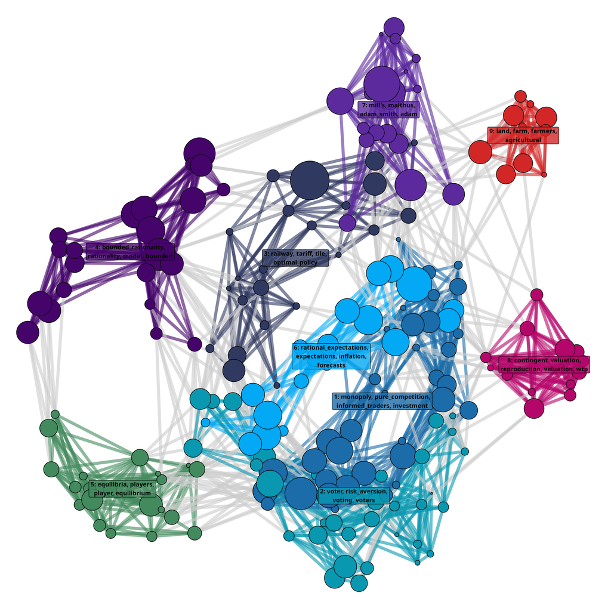

```r
sentences[, size_window := .N, by = window]
sentences[,
  proportion_hdbscan_cluster := .N / size_window,
  by = .(HDBSCAN_cluster, window)
]
backbone_network <- backbone_network %>%
  activate("nodes") %>%
  left_join(
    sentences %>%
      distinct(
        cluster_id,
        HDBSCAN_cluster,
        backbone_community,
        label_hdbscan_cluster,
        label_backbone_community,
        proportion_hdbscan_cluster
      ),
    by = "cluster_id"
  )

backbone_network <- backbone_network %>%
  activate("edges") %>%
  mutate(
    community_from = .N()[["community"]][from],
    community_to = .N()[["community"]][to],
    edge_community = if_else(
      community_from == community_to,
      community_from,
      NA_character_
    ),
    edge_community = factor(edge_community, levels = comm_levels)
  )

# compute layout and community centroids
set.seed(89)
layout <- ggraph::create_layout(backbone_network, layout = "fr")

community_average <- layout %>%
  as_tibble() %>%
  group_by(community) %>%
  summarize(
    x = mean(x, na.rm = TRUE),
    y = mean(y, na.rm = TRUE),
    .groups = "drop"
  ) %>%
  left_join(
    layout %>% as_tibble() %>% distinct(community, label_backbone_community),
    by = "community"
  )

# plot: edges coloured by edge_community when endpoints share same community, otherwise grey
backbone_network_plot <- ggraph(layout) +
  geom_edge_link(
    aes(colour = edge_community),
    alpha = 0.6,
    width = 2,
    show.legend = FALSE
  ) +
  geom_node_point(
    aes(fill = community, size = proportion_hdbscan_cluster),
    show.legend = FALSE,
    shape = 21
  ) +
  geom_label(
    data = community_average,
    aes(
      x = x,
      y = y,
      label = str_wrap(label_backbone_community, 30),
      fill = community
    ),
    size = 3,
    fontface = "bold",
    alpha = 0.8,
    show.legend = FALSE
  ) +
  scale_edge_width(range = c(0.2, 3)) +
  scale_size_continuous(range = c(1, 25)) +
  labs(edge_width = "Avg similarity") +
  scale_edge_color_manual(values = cluster_colors, na.value = "grey80") +
  scale_fill_manual(values = cluster_colors) +
  theme_void()

ggsave(
  here("pictures", "backbone_communities_network.png"),
  backbone_network_plot,
  units = "cm",
  width = 30,
  height = 30,
  dpi = 300
)

knitr::include_graphics(here("pictures", "backbone_communities_network.png"))
```

```r
p_load(ggiraph)

set.seed(89)
backbone_network_ggiraph_plot <- ggraph(layout) +
  geom_edge_link(
    aes(colour = edge_community),
    alpha = 0.6,
    width = 2,
    show.legend = FALSE
  ) +
  # interactive node points: tooltip = label_hdbscan_cluster, data_id = cluster_id
  geom_point_interactive(
    aes(
      x = x,
      y = y,
      fill = community,
      size = proportion_hdbscan_cluster,
      tooltip = str_c(
        label_hdbscan_cluster,
        "\nPeriod:",
        window,
        "\nProportion of sentences in window: ",
        round(proportion_hdbscan_cluster * 100, 2),
        "%"
      ),
      data_id = cluster_id
    ),
    show.legend = FALSE,
    shape = 21
  ) +
  scale_size_continuous(range = c(1, 20)) +
  labs(edge_width = "Avg similarity") +
  scale_edge_color_manual(values = cluster_colors, na.value = "grey80") +
  scale_fill_manual(values = cluster_colors) +
  theme_void()

# create interactive girafe object with sensible hover/tooltip styling
girafe_obj <- ggiraph::girafe(
  ggobj = backbone_network_ggiraph_plot,
  width_svg = 16,
  height_svg = 10,
  options = list(
    ggiraph::opts_selection(type = "single"),
    ggiraph::opts_zoom(min = 1, max = 12), # wheel to zoom, drag to pan
    ggiraph::opts_toolbar(position = "topright")
  )
)

girafe_obj
```

[interactive chart not shown]

The next visualisation takes the same nodes and edges but repositions the nodes in a temporal layout, with time on the x-axis and communities stacked on the y-axis. It allows to see how backbone communities evolve over time.

```r
# per-window equally spaced y to avoid overlap
nodes_pos <- backbone_network %>%
    activate("nodes") %>%
    as_tibble(.name_repair = "minimal") |>
    mutate(x = as.integer(factor(window, levels = window_levels))) |>
  group_by(window) %>%
  arrange(desc(community), .by_group = TRUE) %>%
  mutate(
    n_in_window = n(),
    y = ifelse(n_in_window == 1, 0, seq(-1, 1, length.out = n_in_window))
  ) %>%
  ungroup()

# distribute nodes vertically within each (community, window) cell to avoid overlap
# compute per-(community,x) offsets without calling seq() on a vector
# compute required band per community (max nodes in any x for that community)
comm_band <- nodes_pos %>%
  mutate(community = factor(community, levels = comm_levels)) %>%
  group_by(community, x) %>%
  summarise(n_in_cell = n(), .groups = "drop") %>%
  group_by(community) %>%
  summarise(
    max_in_column = max(n_in_cell, na.rm = TRUE),
    .groups = "drop"
  ) %>%
  arrange(community) %>%
  mutate(
    max_in_column = pmax(max_in_column, 1L),
    pad = 0.7, # vertical padding between community bands
    band = max_in_column + pad # total vertical band height for the community
  ) %>%
  mutate(
    baseline = cumsum(lag(band, default = 0)) + band / 2 # center y for each community band
  ) %>%
  select(community, band, baseline)

# assign nodes within their community/x band
nodes_pos <- nodes_pos %>%
  mutate(community = factor(community, levels = comm_levels)) %>%
  left_join(comm_band, by = "community") %>%
  group_by(community, x) %>%
  arrange(window, cluster_id, .by_group = TRUE) %>%
  mutate(
    n_in_cell = n(),
    # centered offsets inside the community band; works for n_in_cell == 1 as well
    offset = (row_number() - 0.5) * band / n_in_cell - band / 2,
    y = baseline + offset
  ) %>%
  ungroup() %>%
  select(cluster_id, x, y, community)

# join positions into the graph nodes (match keys exactly)
temporal_backbone_network <- backbone_network %>%
  activate("nodes") %>%
  left_join(nodes_pos, by = c("cluster_id", "community"))

# compute label positions for communities (uses comm_band and layout from above)
community_label_positions <- comm_band %>%
  left_join(
    layout %>% as_tibble() %>% distinct(community, label_backbone_community),
    by = "community"
  ) %>%
  arrange(match(community, comm_levels)) %>%
  mutate(label = str_wrap(label_backbone_community, 40))

temporal_network_plot <- ggraph(
  temporal_backbone_network,
  layout = "manual",
  x = x,
  y = y
) +
  geom_edge_link(
    aes(colour = edge_community),
    alpha = 0.5,
    show.legend = FALSE,
    width = 2
  ) +
  geom_label(
    aes(
      x = x,
      y = y,
      label = cluster_id,
      fill = community,
      size = proportion_hdbscan_cluster
    ),
    label.padding = unit(0.12, "lines"),
    show.legend = FALSE,
    alpha = 0.9
  ) +
  scale_fill_manual(values = cluster_colors) +
  scale_edge_color_manual(values = cluster_colors, na.value = "grey80") +
  scale_x_continuous(
    breaks = seq_along(window_levels),
    labels = window_levels
  ) +
  # y axis showing community labels at their baseline positions
  scale_y_continuous(
    breaks = community_label_positions$baseline,
    labels = community_label_positions$label,
    expand = expansion(add = c(1, 0.8))
  ) +
  scale_size_continuous(range = c(3, 10)) +
  labs(x = NULL, y = NULL) +
  theme_minimal() +
  theme(
    panel.grid = element_blank(),
    axis.title.y = element_blank(),
    axis.text.y = element_text(size = 8, hjust = 1),
    axis.ticks.y = element_line(color = "grey50"),
    axis.line.y = element_line(color = "grey50"),
    axis.line.x = element_line(color = "grey50"),
    axis.ticks.x = element_line(color = "grey50"),
    axis.text.x = element_text(angle = 45, hjust = 1, vjust = 1, size = 9)
  )

ggsave(
  here("pictures", "temporal_network_plot.png"),
  temporal_network_plot,
  units = "cm",
  width = 30,
  height = 30,
  dpi = 300
)
```

```r
temporal_network_ggiraph_plot <- ggraph(
  temporal_backbone_network,
  layout = "manual",
  x = x,
  y = y
) +
  geom_edge_link(
    aes(colour = edge_community),
    alpha = 0.5,
    show.legend = FALSE
  ) +
  geom_point_interactive(
    aes(
      x = x,
      y = y,
      fill = community,
      size = proportion_hdbscan_cluster,
      tooltip = str_c(
        label_hdbscan_cluster,
        "\nPeriod:",
        window,
        "\nProportion of sentences in window: ",
        round(proportion_hdbscan_cluster * 100, 2),
        "%"
      ),
      data_id = cluster_id
    ),
    show.legend = FALSE,
    shape = 21,
    alpha = 0.9
  ) +
  scale_fill_manual(values = cluster_colors) +
  scale_edge_color_manual(values = cluster_colors, na.value = "grey80") +
  scale_x_continuous(
    breaks = seq_along(window_levels),
    labels = window_levels
  ) +
  # y axis showing community labels at their baseline positions
  scale_y_continuous(
    breaks = community_label_positions$baseline,
    labels = community_label_positions$label,
    expand = expansion(add = c(0.9, 0.9))
  ) +
  scale_size_continuous(range = c(2, 15)) +
  labs(x = NULL, y = NULL) +
  theme_minimal() +
  theme(
    panel.grid = element_blank(),
    axis.title.y = element_blank(),
    axis.text.y = element_text(size = 10, hjust = 1),
    axis.ticks.y = element_line(color = "grey50"),
    axis.line.y = element_line(color = "grey50"),
    axis.line.x = element_line(color = "grey50"),
    axis.ticks.x = element_line(color = "grey50"),
    axis.text.x = element_text(angle = 45, hjust = 1, vjust = 1, size = 9)
  )

# create interactive girafe object with sensible hover/tooltip styling
girafe_obj_time <- ggiraph::girafe(
  ggobj = temporal_network_ggiraph_plot,
  width_svg = 16,
  height_svg = 10,
  options = list(
    ggiraph::opts_selection(type = "single"),
    opts_tooltip(use_fill = TRUE),
    ggiraph::opts_zoom(min = 1, max = 12), # wheel to zoom, drag to pan
    ggiraph::opts_toolbar(position = "topright")
  )
)

girafe_obj_time
```

[interactive chart not shown]

## Description of the clusters: a reader’s guide

A series of indicators are produced for each clusters. Here are some explanations on how to read them.

### Header summary

**Note**

**What this shows**: size, time span, and main sources of the cluster.  
**How to read**:  
- **Sentences and share**: number of sentences in this cluster and its share of all analysed sentences.  
- **Period**: first and last window where this cluster appears.  
- **Recurring authors/journals**: most frequent contributors by sentence count.  
**Notes**: counts are sentence-level. Long papers can contribute many sentences.

### Top TF-IDF terms describing the community

**Tip**

**What this shows**: words or two-word phrases most specific to this intertemporal backbone community over the full period, in comparison to all other backbone communities.  
**How to read**: higher TF-IDF = greater within-cluster distinctiveness. Compare terms within this table.  
**Use**: quick topic fingerprint.  
**Caution**: This is not an “absolute” TF-IDF: to take into account the fact that more recent periods have more sentences, we average TF-IDF calculated at the window level.

### Top TF-IDF terms by kmean cluster

**Tip**

**What this shows**: the kmean cluster’s distinctive vocabulary.  
**How to read**: compare kmean clusters within the same backbone community to see terms that appear or fade.  
**Use**: detect shifts in focus, methods, or cases across time, as well as diversity within a backbone community.

### Distribution of sentences over time

**Note**

**What this shows**: yearly counts of sentences in this cluster.  
**How to read**: bars = activity level. Peaks = years with more writing on this theme.  
**Caution**: absolute counts, not shares. Later years may have more total publishing.

### Closest sentences from “rationality” and “rational” embeddings within the backbone community

**Note**

**What this shows**: sentences that have the highest cosine similarity with the “rational”/“rationality” embeddings  
**How to read**: examples of how this community talks about the future.  
**Caution**: ranked by the proximity with “rational”/“rationality” embeddings, not by the proximity with the centroid of the cluster (i.e. the average point in the cluster).

### Closest sentences to the backbone community centroid

**Note**

**What this shows**: sentences most representative of the backbone community’s core meaning.  
**How to read**: scan to grasp the cluster’s center. These sentences help to grasp what’s the cluster is about, but not necessarily how it talks about the future. **Caution**: this has been calculated by averaging the embeddings of all sentences in the backbone community, and then finding the sentences closest to this centroid. May be biased towards more recent periods when the community grew over time.

### Closest sentences to the kmean cluster centroids

**Tip**

### Top articles (most sentences) of the backbone community

**Note**

**What this shows**: works contributing the most sentences to this cluster.  
**Columns**: **Number sentences** and **Work Similarity**.  
— **Number sentences**: volume contributed by the work.  
— **Word Similarity**: mean of the cosine similarity to “rationality”/“rational” for that work’s sentences in this cluster.  
**How to read**: Most representative articles of the cluster. Worth clicking on the link to see more about what the article is about. Often a good way to understand how it talks about rationality.

### Top articles (most sentences) of each kmean cluster

**Note**

**What this shows**: same as above, but split by kmean cluster.  
**How to read**: see which articles contribute to which kmean clusters within the backbone community

### Most cited references in the backbone community

**Note**

**What this shows**: the references most often cited by the articles that contribute sentences to this community.

**Columns**  
- **First Author / Year / Journal**: metadata from the reference list.  
- **Citation by article**: number of *distinct articles in this cluster* that cite the reference.  
- **Citation by sentence**: **Citation by article** weighted by how many sentences those citing articles contribute to the cluster (higher = the reference is cited by more central articles in this cluster).

**How to read**: prefer **Citation by sentence** to identify anchors of the cluster; use **Citation by article** to see breadth of citing articles.

**Caveats**  
- The second table lists references *without stable IDs*. This helps recovering books but may be inaccurate.  
- Weighting captures cluster centrality of the *citing articles*, not the number of in-text mentions.  
- Abbreviated journal names may vary.

### Most cited references in each kmean clusters

**Tip**

**What this shows**: decade-level leaders by the same two indicators. **How to read**: compare decades and clusters in same decate to see which references anchor the community at different times.

### Column legend

- **Sentence**: quoted sentence.
- **Title**: clickable article title.
- **Year**: publication year.
- **Journal**: outlet.
- **Authors**: as listed.
- **Words Similarity**: cosine similarity to the embeddings of “rational”/“rationality”.
- **Centroid Similarity**: cosine similarity to the cluster’s centroid.
- **Distance to centroid**: distance to the kmean cluster’s centroid.
- **Number sentences**: sentences from that work in this cluster.

### General cautions

- Similarity values lie in [0,1]. Near-top differences can still matter.
- TF-IDF is comparative within this dataset.
- All counts reflect the top-1% sentences set used here.

# Description of the Clusters

```r
for (cluster in list_clusters) {
  cluster_data <- sentences %>%
    arrange(window) |>
    filter(backbone_community == !!cluster) %>%
    mutate(title = glue("<a href='{url}' target='_blank'>{title}</a>"))

  cluster_name <- cluster_data %>%
    pull(label_backbone_community) %>%
    unique

  hdbscan_clusters <- cluster_data %>%
    distinct(HDBSCAN_cluster, window, cluster_id)

  # extracting the first year and last year of the community
  window <- c(
    first(unique(cluster_data$window)) %>% str_extract("^\\d{4}"),
    last(unique(cluster_data$window)) %>% str_extract("\\d{4}$")
  )

  ################ Beginning of the template ######################
  cat(sprintf("  \n## Intertemporal cluster _%s_ \n\n", cluster_name))

  ############# General Info ##################
  cat(paste0(
    "  \nThe cluster gathers ",
    nrow(distinct(cluster_data, sentence_id, id)),
    " sentences from our corpus. It represents ",
    round(
      nrow(distinct(cluster_data, id, sentence_id)) /
        nrow(distinct(sentences, id, sentence_id)) *
        100,
      2
    ),
    "% of all the sentences selected over the whole period.\n"
  ))

  cat(paste0(
    "\nThe community exists from ",
    window[1],
    " to ",
    window[2],
    ". \n\n"
  ))

  recurring_authors <- cluster_data %>%
    filter(!is.na(authors)) %>%
    select(authors, id) %>%
    separate_longer_delim(authors, delim = ", ") %>%
    # unnest(authors) %>%
    add_count(authors, name = "nb_sentences") %>%
    distinct(authors, id, nb_sentences) %>%
    add_count(authors, name = "nb_articles") %>%
    distinct(authors, nb_sentences, nb_articles) %>%
    slice_max(order_by = nb_sentences, n = 15)
  cat(paste0(
    "The most recurring authors are ",
    paste0(
      recurring_authors$authors,
      " (",
      recurring_authors$nb_sentences,
      " sentences; ",
      recurring_authors$nb_articles,
      " articles)",
      collapse = ", "
    ),
    ".\n\n"
  ))

  recurring_journals <- cluster_data %>%
    select(journal, id) %>%
    add_count(journal, name = "nb_sentences") %>%
    distinct(journal, id, nb_sentences) %>%
    add_count(journal, name = "nb_articles") %>%
    distinct(journal, nb_sentences, nb_articles) %>%
    slice_max(order_by = nb_sentences, n = 6)
  cat(paste0(
    "The most recurring journals are ",
    paste0(
      recurring_journals$journal,
      " (",
      recurring_journals$nb_sentences,
      " sentences; ",
      recurring_journals$nb_articles,
      " articles)",
      collapse = ", "
    ),
    ".\n\n"
  ))

  ############# TF-IDF ##################
  cat("\n### Top TF-IDF terms describing the community\n\n")
  # Extracting top terms in general and for window
  top_terms_cluster %>%
    filter(backbone_community == !!cluster) %>%
    select(token, mean_tf_idf) %>%
    kbl(col.names = c("Token", "TF-IDF")) %>%
    kable_styling(
      bootstrap_options = c("striped", "condensed"),
      font_size = 15
    ) %>%
    print()

  if (nrow(hdbscan_clusters) > 1) {
    cat(
      "\n### Top TF-IDF terms describing the different k-means clusters\n\n"
    )

    for (hdbscan_id in hdbscan_clusters$cluster_id) {
      time_window <- hdbscan_clusters %>%
        filter(cluster_id == hdbscan_id) %>%
        pull(window)

      hdbscan <- hdbscan_clusters %>%
        filter(cluster_id == hdbscan_id) %>%
        pull(HDBSCAN_cluster)

      cat(
        glue(
          "\n#### Top terms {cluster_data[cluster_id == hdbscan_id,]$label_hdbscan_cluster |> unique()} ({time_window})\n\n"
        ),
        sep = ""
      )

      top_terms_hdbscan_cluster %>%
        filter(window == time_window, HDBSCAN_cluster == hdbscan) %>%
        select(token, tf_idf) %>%
        kbl(col.names = c("Token", "TF-IDF")) %>%
        kable_styling(
          bootstrap_options = c("striped", "condensed"),
          font_size = 11
        ) %>%
        print()
    }
  }

  ############# Distribution sentences ##################
  cat("\n### Distribution of sentences over time \n\n")

  plot(
    cluster_data %>%
      count(year) %>%
      ggplot(aes(x = year, y = n)) +
      geom_bar(stat = "identity") +
      scale_x_continuous(expand = c(0.01, 0), n.breaks = 10) +
      scale_y_continuous(expand = c(0.01, 0)) +
      theme_light(base_size = 20) +
      labs(y = "Number of sentences", x = NULL, title = NULL)
  )

  ####### Top Sentences ###################
  top_sentences_rationality_filtered <- top_sentences_rationality %>%
    filter(backbone_community == !!cluster) %>%
    left_join(distinct(
      cluster_data,
      title,
      journal,
      authors,
      url,
      sentence_id,
      id
    )) %>%
    mutate(title = glue("<a href='{url}' target='_blank'>{title}</a>"))

  top_sentences_hdbscan_cluster_centroid_filtered <- top_sentences_hdbscan_cluster_centroid %>%
    filter(backbone_community == !!cluster) %>%
    left_join(
      distinct(
        cluster_data,
        title,
        year,
        journal,
        authors,
        id,
        sentence_id,
        url
      ),
      by = c("sentence_id", "id")
    ) %>%
    mutate(title = glue("<a href='{url}' target='_blank'>{title}</a>"))

  top_sentences_backbone_community_centroid_filtered <- top_sentences_backbone_community_centroid %>%
    filter(backbone_community == !!cluster) %>%
    left_join(
      distinct(
        cluster_data,
        title,
        year,
        journal,
        authors,
        id,
        sentence_id,
        url
      ),
      by = c("sentence_id", "id")
    ) %>%
    mutate(title = glue("<a href='{url}' target='_blank'>{title}</a>"))

  ############# Top sentences rationality ##################
  cat("\n\n")
  cat(
    "\n### Closest sentence from 'rational' and 'rationality' of the backbone community\n\n"
  )

  top_sentences_rationality_filtered %>%
    slice_max(similarity, n = 20, by = backbone_community) %>%
    select(
      sentence,
      title,
      year,
      journal,
      authors,
      similarity
    ) %>%
    kbl(
      escape = FALSE,
      col.names = c(
        "Sentence",
        "Title",
        "Year",
        "Journal",
        "Authors",
        "Words Similarity"
      )
    ) %>%
    kable_styling(
      bootstrap_options = c("striped", "condensed"),
      font_size = 12
    ) %>%
    column_spec(2, "3.5cm") %>%
    print()
```

```r
  ############# Top sentences centroid ##################
  cat("\n### Closest sentences of the backbone community's centroid\n\n")

  top_sentences_backbone_community_centroid_filtered %>%
    slice_max(similarity_backbone_centroid, n = 15) %>%
    select(
      sentence,
      title,
      year,
      journal,
      authors,
      similarity_backbone_centroid
    ) %>%
    kbl(
      escape = FALSE,
      col.names = c(
        "Sentence",
        "Title",
        "Year",
        "Journal",
        "Authors",
        "Similarity to Backbone Centroid"
      )
    ) %>%
    kable_styling(
      bootstrap_options = c("striped", "condensed"),
      font_size = 13
    ) %>%
    column_spec(2, "3.5cm") %>%
    print()

  if (nrow(hdbscan_clusters) > 1) {
    cat(
      "\n### Closest sentences of each HDBSCAN cluster's centroid composing the backbone community\n\n"
    )

    for (hdbscan_id in unique(cluster_data$cluster_id)) {
      time_window <- hdbscan_clusters %>%
        filter(cluster_id == hdbscan_id) %>%
        pull(window)

      hdbscan <- hdbscan_clusters %>%
        filter(cluster_id == hdbscan_id) %>%
        pull(HDBSCAN_cluster)

      cat(
        glue(
          "\n#### Closes sentences {cluster_data[cluster_id == hdbscan,]$label_hdbscan_cluster |> unique()} ({time_window})\n\n"
        ),
        sep = ""
      )

      top_sentences_hdbscan_cluster_centroid_filtered %>%
        filter(window == time_window, HDBSCAN_cluster == hdbscan) %>%
        slice_max(similarity_hdbscan_centroid, n = 10) %>%
        select(
          sentence,
          title,
          year,
          journal,
          authors,
          similarity_hdbscan_centroid
        ) %>%
        kbl(
          escape = FALSE,
          col.names = c(
            "Sentence",
            "Title",
            "Year",
            "Journal",
            "Authors",
            "Similarity to HDSBSCAN Centroid"
          )
        ) %>%
        kable_styling(
          bootstrap_options = c("striped", "condensed"),
          font_size = 12
        ) %>%
        column_spec(2, "3.5cm") %>%
        print()
    }
  }

  ############# Top articles ##################
  cat("\n### Top articles (most sentences) of the backbone cluster\n\n")
  # Extracting top terms in general and for window
  cluster_data |>
    mutate(
      mean_similarity = mean(similarity_rv) %>% round(3),
      n = n(),
      .by = id
    ) %>%
    distinct(
      title,
      year,
      journal,
      authors,
      n,
      mean_similarity
    ) |>
    slice_max(n, n = 15, with_ties = FALSE) %>%
    kbl(
      escape = FALSE,
      col.names = c(
        "Title",
        "Year",
        "Journal",
        "Authors",
        "Number sentences",
        "Words Similarity"
      )
    ) %>%
    kable_styling(
      bootstrap_options = c("striped", "condensed"),
      font_size = 13
    ) %>%
    print()

  if (nrow(hdbscan_clusters) > 1) {
    cat(
      "\n### Top articles (most sentences) of the cluster for each time window{.panel-tabset}\n\n"
    )

    for (hdbscan_id in unique(cluster_data$cluster_id)) {
      time_window <- hdbscan_clusters %>%
        filter(cluster_id == hdbscan_id) %>%
        pull(window)

      hdbscan <- hdbscan_clusters %>%
        filter(cluster_id == hdbscan_id) %>%
        pull(HDBSCAN_cluster)
      cat(
        glue(
          "\n#### Top articles for {cluster_data[cluster_id == hdbscan,]$label_hdbscan_cluster |> unique()} ({time_window})\n\n"
        ),
        sep = ""
      )

      cluster_data %>%
        filter(window == time_window, HDBSCAN_cluster == hdbscan) %>%
        mutate(
          mean_similarity = mean(similarity_rv) %>% round(3),
          n = n(),
          .by = id
        ) %>%
        distinct(
          title,
          year,
          journal,
          authors,
          n,
          mean_similarity
        ) %>%
        slice_max(n, n = 10, with_ties = FALSE) %>%
        kbl(
          escape = FALSE,
          col.names = c(
            "Title",
            "Year",
            "Journal",
            "Authors",
            "Number sentences",
            "Words Similarity"
          )
        ) %>%
        kable_styling(
          bootstrap_options = c("striped", "condensed"),
          font_size = 13
        ) %>%
        print()
    }
  }

  ############## Top References ##################
  cat("\n### Most cited references in the backbone community\n\n")

  top_refs %>%
    filter(backbone_community == cluster) %>%
    distinct(Nom, Annee, Revue_Abbrege, absolute_cit, weighted_cit) %>%
    filter(absolute_cit > 1) |>
    slice_max(weighted_cit, n = 15, with_ties = FALSE) %>%
    kbl(
      escape = FALSE,
      col.names = c(
        "First Author",
        "Year",
        "Journal",
        "Citation by article",
        "Citation by sentence"
      )
    ) %>%
    kable_styling(
      bootstrap_options = c("striped", "condensed"),
      font_size = 12
    ) %>%
    print()

  top_refs_without_id %>%
    filter(backbone_community == cluster) %>%
    distinct(Nom, Annee, Revue_Abbrege, absolute_cit, weighted_cit) %>%
    filter(absolute_cit > 1) |>
    slice_max(weighted_cit, n = 15, with_ties = FALSE) %>%
    kbl(
      escape = FALSE,
      col.names = c(
        "First Author",
        "Year",
        "Journal",
        "Citation by article",
        "Citation by sentence"
      )
    ) %>%
    kable_styling(
      bootstrap_options = c("striped", "condensed"),
      font_size = 12
    ) %>%
    print()

  if (nrow(hdbscan_clusters) > 1) {
    cat("\n### Most cited references per kmean clusters\n\n")

    for (hdbscan_id in unique(cluster_data$cluster_id)) {
      time_window <- hdbscan_clusters %>%
        filter(cluster_id == hdbscan_id) %>%
        pull(window)

      hdbscan <- hdbscan_clusters %>%
        filter(cluster_id == hdbscan_id) %>%
        pull(HDBSCAN_cluster)

      top_ref_cluster <- top_refs %>%
        filter(window == time_window, HDBSCAN_cluster == hdbscan) %>%
        distinct(
          Nom,
          Annee,
          Revue_Abbrege,
          absolute_cluster_cit,
          weighted_cluster_cit
        ) %>%
        slice_max(weighted_cluster_cit, n = 10, with_ties = FALSE)
```

```r
      top_ref_without_id_cluster <- top_refs_without_id %>%
        filter(window == time_window, HDBSCAN_cluster == hdbscan) %>%
        distinct(
          Nom,
          Annee,
          Revue_Abbrege,
          absolute_cluster_cit,
          weighted_cluster_cit
        ) %>%
        slice_max(weighted_cluster_cit, n = 10, with_ties = FALSE)

      if (nrow(top_ref_cluster) != 0 | nrow(top_ref_without_id_cluster) != 0) {
        cat(
          glue(
            "\n#### Most cited references for {cluster_data[cluster_id == hdbscan,]$label_hdbscan_cluster |> unique()} ({time_window})\n\n"
          ),
          sep = ""
        )
        if (nrow(top_ref_cluster) > 0) {
          top_ref_cluster %>%
            kbl(
              escape = FALSE,
              col.names = c(
                "First Author",
                "Year",
                "Journal",
                "Citation by article",
                "Citation by sentence"
              )
            ) %>%
            kable_styling(
              bootstrap_options = c("striped", "condensed"),
              font_size = 12
            ) %>%
            print()
        }

        if (nrow(top_ref_without_id_cluster) > 0) {
          top_ref_without_id_cluster %>%
            kbl(
              escape = FALSE,
              col.names = c(
                "First Author",
                "Year",
                "Journal",
                "Citation by article",
                "Citation by sentence"
              )
            ) %>%
            kable_styling(
              bootstrap_options = c("striped", "condensed"),
              font_size = 12
            ) %>%
            print()
        }
      }
    }
  }
}
```

## Intertemporal cluster *1: monopoly, pure_competition, informed_traders, investment*

The cluster gathers 52399 sentences from our corpus. It represents 19.34% of all the sentences selected over the whole period.

The community exists from 1900 to 2009.

The most recurring authors are Jr. (361 sentences; 202 articles), Hirshleifer D. (220 sentences; 6 articles), Andrei Shleifer (188 sentences; 18 articles), Lawrence H. Summers (177 sentences; 24 articles), Stephen A. Ross (157 sentences; 25 articles), Jiang Wang (140 sentences; 8 articles), David Hirshleifer (138 sentences; 9 articles), Avanidhar Subrahmanyam (110 sentences; 11 articles), Jeremy C. Stein (107 sentences; 22 articles), Verma R. (107 sentences; 4 articles), Robert J. Waldmann (105 sentences; 3 articles), Joseph E. Stiglitz (95 sentences; 42 articles), Leonid Kogan (94 sentences; 1 articles), Mark M. Westerfield (94 sentences; 1 articles), David Easley (87 sentences; 10 articles).

The most recurring journals are The Journal of Finance (3665 sentences; 1260 articles), The American Economic Review (2898 sentences; 1531 articles), Journal of Financial Economics (2061 sentences; 563 articles), The Quarterly Journal of Economics (1495 sentences; 771 articles), Journal of Economic Dynamics and Control (1455 sentences; 479 articles), Journal of Political Economy (1378 sentences; 762 articles).

### Top TF-IDF terms describing the community

| Token | TF-IDF |
| --- | --- |
| monopoly | 0.0041541 |
| pure_competition | 0.0036829 |
| informed_traders | 0.0032105 |
| investment | 0.0031916 |
| real_options | 0.0030900 |
| irrational_traders | 0.0028594 |
| traders | 0.0027759 |
| competition | 0.0026093 |
| noise_traders | 0.0024085 |
| profit_motive | 0.0023990 |
| tlle | 0.0022820 |
| asset_pricing | 0.0022447 |
| deflation | 0.0022371 |
| arbitrage | 0.0020956 |
| premium_puzzle | 0.0020629 |
| irreversible_investment | 0.0020596 |
| investors | 0.0020550 |
| investment_decisions | 0.0020427 |
| perfect_competition | 0.0019925 |
| overconfident | 0.0019876 |

### Top TF-IDF terms describing the different k-means clusters

#### Top terms 1_4_1900-1919: price_fixing, price, price_determination, tho, prices (1900-1919)

| Token | TF-IDF |
| --- | --- |
| price_fixing | 0.0056223 |
| price | 0.0047561 |
| price_determination | 0.0042859 |
| tho | 0.0038946 |
| prices | 0.0034988 |
| price_equation | 0.0033921 |
| fixing | 0.0033548 |
| transport | 0.0030691 |
| commodity | 0.0028862 |
| merchants | 0.0028709 |
| finished | 0.0028709 |
| normal_price | 0.0028111 |
| omniscient | 0.0026993 |
| sold | 0.0023812 |
| rising | 0.0023477 |

#### Top terms 1_2_1900-1919: capital, depreciation, diminishing_returns, circulating, fisher’s (1900-1919)

| Token | TF-IDF |
| --- | --- |
| capital | 0.0099481 |
| depreciation | 0.0085479 |
| diminishing_returns | 0.0064920 |
| circulating | 0.0059924 |
| fisher’s | 0.0045199 |
| exigencies | 0.0043122 |
| capitalization | 0.0042225 |
| unearned | 0.0039949 |
| diminishing | 0.0039254 |
| fair_return | 0.0037294 |
| investor | 0.0033184 |
| condemned | 0.0029614 |
| adam_smith | 0.0025968 |
| rural | 0.0022820 |
| tlle | 0.0022820 |

#### Top terms 1_8_1900-1919: business, employers, scientific, management, business_activity (1900-1919)

| Token | TF-IDF |
| --- | --- |
| business | 0.0093720 |
| employers | 0.0068395 |
| scientific | 0.0064706 |
| management | 0.0061392 |
| business_activity | 0.0048027 |
| shop | 0.0043453 |
| code | 0.0038992 |
| taylor | 0.0037291 |
| inclusive | 0.0030839 |
| workman | 0.0030320 |
| comparatively | 0.0028921 |
| frederick | 0.0028034 |
| workmen | 0.0026208 |
| pecuniary | 0.0025504 |
| ideals | 0.0024861 |

#### Top terms 1_3_1920-1929: price, prices, price_level, stable_price, price_determination (1920-1929)

| Token | TF-IDF |
| --- | --- |
| price | 0.0049667 |
| prices | 0.0041780 |
| price_level | 0.0040861 |
| stable_price | 0.0032688 |
| price_determination | 0.0021751 |
| price_fixing | 0.0021400 |
| market_price | 0.0021006 |
| price_index | 0.0020549 |
| supply | 0.0020418 |
| producer | 0.0019062 |
| purchasing_power | 0.0017311 |
| demand | 0.0017099 |
| expected_change | 0.0016765 |
| beef | 0.0016344 |
| commodity | 0.0016275 |

#### Top terms 1_2_1920-1929: business_activity, business, invention, entrepreneur, workmen (1920-1929)

| Token | TF-IDF |
| --- | --- |
| business_activity | 0.0083780 |
| business | 0.0065923 |
| invention | 0.0058544 |
| entrepreneur | 0.0050410 |
| workmen | 0.0045718 |
| admission | 0.0044689 |
| profits | 0.0033252 |
| management | 0.0032129 |
| pecuniary | 0.0029661 |
| education | 0.0029406 |
| leviathan | 0.0027669 |
| economic_welfare | 0.0026898 |
| manage | 0.0023713 |
| leadership | 0.0023713 |
| executive’s | 0.0022859 |

#### Top terms 1_1_1920-1929: banker, speculation, capital, investment, stock (1920-1929)

| Token | TF-IDF |
| --- | --- |
| banker | 0.0052861 |
| speculation | 0.0050698 |
| capital | 0.0050059 |
| investment | 0.0043528 |
| stock | 0.0042731 |
| voting | 0.0040589 |
| dividends | 0.0040400 |
| stockholders | 0.0036883 |
| common_stock | 0.0035187 |
| corporation | 0.0035035 |
| actual_investment | 0.0034268 |
| prudent | 0.0030693 |
| investors | 0.0030690 |
| promotes | 0.0030432 |
| steadily | 0.0029781 |

#### Top terms 1_8_1930-1939: price, prices, demand_curve, demand, supply (1930-1939)

| Token | TF-IDF |
| --- | --- |
| price | 0.0049104 |
| prices | 0.0028804 |
| demand_curve | 0.0026840 |
| demand | 0.0025215 |
| supply | 0.0024230 |
| rigidity | 0.0021545 |
| curve | 0.0020290 |
| price_level | 0.0020012 |
| demand_curves | 0.0019349 |
| movements | 0.0018625 |
| price_movements | 0.0018389 |
| price_rigidity | 0.0018025 |
| divisibility | 0.0015483 |
| pricing_process | 0.0015158 |
| commodities | 0.0014716 |

#### Top terms 1_4_1930-1939: capital, investment, disinvestment, reinvestment, overinvestment (1930-1939)

| Token | TF-IDF |
| --- | --- |
| capital | 0.0096259 |
| investment | 0.0089152 |
| disinvestment | 0.0041911 |
| reinvestment | 0.0041495 |
| overinvestment | 0.0033675 |
| acceleration_principle | 0.0033529 |
| acceleration | 0.0025628 |
| capital_theory | 0.0025628 |
| invested | 0.0023619 |
| investments | 0.0022518 |
| cent | 0.0022023 |
| intact | 0.0021168 |
| invested_capital | 0.0020747 |
| money_capital | 0.0020205 |
| fixed_capital | 0.0019698 |

#### Top terms 1_3_1930-1939: entrepreneurs, entrepreneur, business, profits, profit (1930-1939)

| Token | TF-IDF |
| --- | --- |
| entrepreneurs | 0.0065147 |
| entrepreneur | 0.0054364 |
| business | 0.0048861 |
| profits | 0.0045138 |
| profit | 0.0041965 |
| anticipations | 0.0039235 |
| enterprise | 0.0037754 |
| entrepreneurial | 0.0037722 |
| net_income | 0.0031966 |
| entrepreneur’s | 0.0023997 |
| commonly_held | 0.0021790 |
| business_enterprise | 0.0021790 |
| management | 0.0020999 |
| salary | 0.0020421 |
| sensibly | 0.0019608 |

#### Top terms 1_7_1930-1939: monopoly, competition, perfect_competition, pure_competition, imperfect_competition (1930-1939)

| Token | TF-IDF |
| --- | --- |
| monopoly | 0.0257602 |
| competition | 0.0176993 |
| perfect_competition | 0.0137195 |
| pure_competition | 0.0133875 |
| imperfect_competition | 0.0058958 |
| free_competition | 0.0057497 |
| imperfection | 0.0057057 |
| monopoly_power | 0.0044909 |
| noncompetitive | 0.0035182 |
| perfect | 0.0032954 |
| insuperable | 0.0030576 |
| restrained | 0.0029331 |
| robinson | 0.0027645 |
| public_utility | 0.0027136 |
| regulated | 0.0025004 |

#### Top terms 1_1_1940-1949: investment, investment_decisions, capital, real_capital, investor (1940-1949)

| Token | TF-IDF |
| --- | --- |
| investment | 0.0104991 |
| investment_decisions | 0.0053465 |
| capital | 0.0047985 |
| real_capital | 0.0044405 |
| investor | 0.0043164 |
| invest | 0.0034588 |
| private_investment | 0.0031000 |
| securities | 0.0030203 |
| investments | 0.0029677 |
| real_investment | 0.0027312 |
| intact | 0.0025037 |
| stocks | 0.0021582 |
| equipment | 0.0021447 |
| focus | 0.0018802 |
| investing | 0.0017124 |

#### Top terms 1_7_1940-1949: price_control, price, price_policy, pricing, prices (1940-1949)

| Token | TF-IDF |
| --- | --- |
| price_control | 0.0068699 |
| price | 0.0055192 |
| price_policy | 0.0046740 |
| pricing | 0.0041985 |
| prices | 0.0038324 |
| price_system | 0.0034970 |
| cost_pricing | 0.0029605 |
| pricing_system | 0.0025193 |
| price_level | 0.0024052 |
| price_structure | 0.0022871 |
| price_decisions | 0.0019042 |
| elasticity | 0.0016870 |
| elastic | 0.0016697 |
| demand | 0.0015817 |
| average_cost | 0.0014606 |

#### Top terms 1_4_1940-1949: profit_motive, entrepreneur, profit, business, entrepreneur’s (1940-1949)

| Token | TF-IDF |
| --- | --- |
| profit_motive | 0.0078306 |
| entrepreneur | 0.0077446 |
| profit | 0.0046770 |
| business | 0.0045681 |
| entrepreneur’s | 0.0045385 |
| profits | 0.0043904 |
| marginalism | 0.0043596 |
| entrepreneurial | 0.0040767 |
| businessmen | 0.0037359 |
| entrepreneurs | 0.0035203 |
| business_behavior | 0.0033288 |
| profit_maximization | 0.0027978 |
| enterprise | 0.0027687 |
| entrepreneurship | 0.0026630 |
| motive | 0.0025552 |

#### Top terms 1_8_1940-1949: monopoly, competition, pure_competition, perfect_competition, imperfect_competition (1940-1949)

| Token | TF-IDF |
| --- | --- |
| monopoly | 0.0281856 |
| competition | 0.0167005 |
| pure_competition | 0.0116078 |
| perfect_competition | 0.0111522 |
| imperfect_competition | 0.0092017 |
| monopolistic | 0.0080456 |
| monopoly_power | 0.0064898 |
| cartel | 0.0045758 |
| deflation | 0.0043529 |
| monopolistic_competition | 0.0041549 |
| imperfect | 0.0037355 |
| perfect | 0.0036511 |
| oligopoly | 0.0029020 |
| lengths | 0.0028341 |
| folly | 0.0025959 |

#### Top terms 1_3_1950-1959: investment, investment_decisions, acceleration_principle, capital, acceleration (1950-1959)

| Token | TF-IDF |
| --- | --- |
| investment | 0.0128502 |
| investment_decisions | 0.0071952 |
| acceleration_principle | 0.0046492 |
| capital | 0.0042369 |
| acceleration | 0.0038767 |
| investment_decision | 0.0034134 |
| investor | 0.0029518 |
| invest | 0.0025142 |
| investment_project | 0.0020355 |
| investments | 0.0019302 |
| investors | 0.0019262 |
| capital_stock | 0.0018318 |
| funds | 0.0018249 |
| stock | 0.0016939 |
| investor’s | 0.0016800 |

#### Top terms 1_8_1950-1959: price, pricing, prices, price_mechanism, price_system (1950-1959)

| Token | TF-IDF |
| --- | --- |
| price | 0.0052017 |
| pricing | 0.0049394 |
| prices | 0.0032180 |
| price_mechanism | 0.0029561 |
| price_system | 0.0028661 |
| cost_pricing | 0.0025542 |
| marginal_cost | 0.0021812 |
| supply | 0.0019298 |
| price_level | 0.0018445 |
| demand | 0.0018056 |
| price_policy | 0.0017642 |
| price_discrimination | 0.0016199 |
| discriminatory | 0.0015041 |
| price_fixing | 0.0014490 |
| commodity | 0.0014326 |

#### Top terms 1_9_1950-1959: monopoly, competition, perfect_competition, pure_competition, workable (1950-1959)

| Token | TF-IDF |
| --- | --- |
| monopoly | 0.0256145 |
| competition | 0.0174634 |
| perfect_competition | 0.0105669 |
| pure_competition | 0.0091655 |
| workable | 0.0073315 |
| imperfect_competition | 0.0056511 |
| monopoly_power | 0.0040995 |
| schumpeter’s | 0.0033567 |
| monopolistic | 0.0031764 |
| free_competition | 0.0029523 |
| harrod | 0.0028398 |
| maximizing_profits | 0.0026178 |
| perfect | 0.0025068 |
| destruction | 0.0023482 |
| oligopolistic | 0.0022914 |

#### Top terms 1_4_1950-1959: businessman, profit_motive, profit, profit_maximization, entrepreneurial (1950-1959)

| Token | TF-IDF |
| --- | --- |
| businessman | 0.0069083 |
| profit_motive | 0.0068575 |
| profit | 0.0057713 |
| profit_maximization | 0.0047471 |
| entrepreneurial | 0.0044626 |
| businessmen | 0.0043126 |
| business_decisions | 0.0037897 |
| entrepreneur | 0.0037419 |
| profits | 0.0035600 |
| managerial | 0.0035104 |
| firm | 0.0033073 |
| maximum_profits | 0.0029581 |
| business | 0.0028443 |
| maximization | 0.0025122 |
| entrepreneurs | 0.0024900 |

#### Top terms 1_11_1960-1969: investment, capital, investment_decisions, investment_decision, projects (1960-1969)

| Token | TF-IDF |
| --- | --- |
| investment | 0.0122485 |
| capital | 0.0050200 |
| investment_decisions | 0.0045715 |
| investment_decision | 0.0034546 |
| projects | 0.0034090 |
| investments | 0.0031390 |
| investment_projects | 0.0030062 |
| stockholder | 0.0029504 |
| capital_stock | 0.0027491 |
| investment_criteria | 0.0024346 |
| stockholders | 0.0022135 |
| stock | 0.0019831 |
| funds | 0.0019620 |
| investor | 0.0018017 |
| investors | 0.0017217 |

#### Top terms 1_7_1960-1969: firm, profit, profits, managerial, profit_maximization (1960-1969)

| Token | TF-IDF |
| --- | --- |
| firm | 0.0058631 |
| profit | 0.0044524 |
| profits | 0.0043547 |
| managerial | 0.0043500 |
| profit_maximization | 0.0036922 |
| management | 0.0036524 |
| managers | 0.0033398 |
| firms | 0.0031849 |
| maximize_profits | 0.0029074 |
| profit_maximizing | 0.0027986 |
| maximization | 0.0026963 |
| corporation | 0.0026173 |
| corporate | 0.0025454 |
| maximize | 0.0024003 |
| businessmen | 0.0023613 |

#### Top terms 1_15_1960-1969: benefit_cost, project, projects, benefits, benefit_analysis (1960-1969)

| Token | TF-IDF |
| --- | --- |
| benefit_cost | 0.0105678 |
| project | 0.0058086 |
| projects | 0.0049749 |
| benefits | 0.0046291 |
| benefit_analysis | 0.0045029 |
| cost_benefit | 0.0044503 |
| benefit | 0.0044428 |
| cost_analysis | 0.0041330 |
| costs | 0.0037736 |
| costing | 0.0035514 |
| sacrificed | 0.0026419 |
| allocation | 0.0026168 |
| broad_sense | 0.0024117 |
| resources | 0.0023770 |
| cost | 0.0023717 |

#### Top terms 1_16_1960-1969: price, prices, pricing, price_system, relative_prices (1960-1969)

| Token | TF-IDF |
| --- | --- |
| price | 0.0052125 |
| prices | 0.0039124 |
| pricing | 0.0036949 |
| price_system | 0.0027759 |
| relative_prices | 0.0023284 |
| price_discrimination | 0.0021811 |
| factor_prices | 0.0020465 |
| price_policy | 0.0018099 |
| demand | 0.0017941 |
| price_stability | 0.0017674 |
| price_structure | 0.0016605 |
| demand_curve | 0.0016540 |
| cost_pricing | 0.0015285 |
| price_theory | 0.0015270 |
| price_ratios | 0.0014275 |

#### Top terms 1_17_1960-1969: monopoly, competition, perfect_competition, market_power, monopolistic (1960-1969)

| Token | TF-IDF |
| --- | --- |
| monopoly | 0.0150118 |
| competition | 0.0127412 |
| perfect_competition | 0.0083948 |
| market_power | 0.0065455 |
| monopolistic | 0.0039308 |
| workable | 0.0036291 |
| monopolistic_competition | 0.0036088 |
| antitrust | 0.0031506 |
| pure_competition | 0.0031506 |
| market | 0.0028615 |
| monopoly_power | 0.0028184 |
| imperfect_competition | 0.0026641 |
| price_competition | 0.0024059 |
| competitive | 0.0023999 |
| market_competition | 0.0019872 |

#### Top terms 1_7_1970-1979: price, prices, pricing, price_system, relative_prices (1970-1979)

| Token | TF-IDF |
| --- | --- |
| price | 0.0049722 |
| prices | 0.0034318 |
| pricing | 0.0024627 |
| price_system | 0.0018051 |
| relative_prices | 0.0017649 |
| demand | 0.0017609 |
| price_level | 0.0016838 |
| firm | 0.0016358 |
| factor_prices | 0.0016047 |
| factor_price | 0.0015740 |
| excess_demand | 0.0014967 |
| firms | 0.0014349 |
| monopoly | 0.0014278 |
| market | 0.0014061 |
| output | 0.0012414 |

#### Top terms 1_11_1970-1979: investment, portfolio, investors, investor, capital (1970-1979)

| Token | TF-IDF |
| --- | --- |
| investment | 0.0076203 |
| portfolio | 0.0064154 |
| investors | 0.0047401 |
| investor | 0.0041505 |
| capital | 0.0032083 |
| investment_decisions | 0.0031979 |
| asset | 0.0030718 |
| risk | 0.0026639 |
| shareholders | 0.0025897 |
| capital_stock | 0.0025075 |
| stockholders | 0.0024692 |
| investment_decision | 0.0024653 |
| portfolios | 0.0023067 |
| capital_asset | 0.0022938 |
| assets | 0.0022307 |

#### Top terms 1_10_1970-1979: firm, profit_maximization, managerial, firms, profit (1970-1979)

| Token | TF-IDF |
| --- | --- |
| firm | 0.0083983 |
| profit_maximization | 0.0074367 |
| managerial | 0.0057304 |
| firms | 0.0052207 |
| profit | 0.0049639 |
| maximization | 0.0044855 |
| profits | 0.0044070 |
| maximize_profits | 0.0038890 |
| profitability | 0.0035990 |
| managers | 0.0034830 |
| enterprise | 0.0032810 |
| profit_maximizing | 0.0032570 |
| firm’s | 0.0031601 |
| maximize | 0.0031344 |
| management | 0.0026022 |

#### Top terms 1_13_1980-1989: asset, arbitrage, markets, traders, investors (1980-1989)

| Token | TF-IDF |
| --- | --- |
| asset | 0.0068196 |
| arbitrage | 0.0050671 |
| markets | 0.0045905 |
| traders | 0.0045313 |
| investors | 0.0045284 |
| information | 0.0038889 |
| asset_pricing | 0.0038766 |
| portfolio | 0.0037410 |
| capm | 0.0036605 |
| efficient_markets | 0.0031686 |
| model | 0.0031673 |
| trading | 0.0031009 |
| stock_prices | 0.0028774 |
| pricing | 0.0028286 |
| asset_prices | 0.0027687 |

#### Top terms 1_14_1980-1989: investment, investment_decisions, capital_stock, investment_decision, capital (1980-1989)

| Token | TF-IDF |
| --- | --- |
| investment | 0.0137143 |
| investment_decisions | 0.0074398 |
| capital_stock | 0.0062078 |
| investment_decision | 0.0044394 |
| capital | 0.0042090 |
| stock | 0.0037047 |
| invest | 0.0029110 |
| investments | 0.0026327 |
| model | 0.0026198 |
| investment_behavior | 0.0023359 |
| uncertainty | 0.0021946 |
| irreversible | 0.0021451 |
| optimal | 0.0020282 |
| irreversibility | 0.0019969 |
| modigliani_miller | 0.0018659 |

#### Top terms 1_12_1980-1989: price, prices, price_level, market_clearing, pricing (1980-1989)

| Token | TF-IDF |
| --- | --- |
| price | 0.0059243 |
| prices | 0.0035897 |
| price_level | 0.0030529 |
| market_clearing | 0.0030416 |
| pricing | 0.0028190 |
| clearing | 0.0026286 |
| model | 0.0025415 |
| price_expectations | 0.0021228 |
| firms | 0.0020955 |
| expectations | 0.0020006 |
| firm | 0.0019033 |
| relative_prices | 0.0017896 |
| factor_price | 0.0017368 |
| demand | 0.0017034 |
| price_adjustment | 0.0016564 |

#### Top terms 1_5_1990-1999: seller, buyer, bidders, buyers, auction (1990-1999)

| Token | TF-IDF |
| --- | --- |
| seller | 0.0056740 |
| buyer | 0.0044802 |
| bidders | 0.0043615 |
| buyers | 0.0037380 |
| auction | 0.0037357 |
| price | 0.0034935 |
| firms | 0.0032522 |
| contestability | 0.0032391 |
| seller’s | 0.0028816 |
| sellers | 0.0028486 |
| firm | 0.0027811 |
| equilibrium | 0.0027160 |
| bidder | 0.0026664 |
| bid | 0.0026461 |
| pricing | 0.0026200 |

#### Top terms 1_7_1990-1999: option, investment, investment_decisions, irreversible_investment, options (1990-1999)

| Token | TF-IDF |
| --- | --- |
| option | 0.0122242 |
| investment | 0.0120098 |
| investment_decisions | 0.0067235 |
| irreversible_investment | 0.0066310 |
| options | 0.0060534 |
| irreversibility | 0.0056203 |
| irreversible | 0.0052826 |
| investment_decision | 0.0047524 |
| invest | 0.0045254 |
| uncertainty | 0.0040979 |
| capital_stock | 0.0037932 |
| quasi_option | 0.0033883 |
| option_pricing | 0.0031932 |
| pindyck | 0.0031729 |
| investors | 0.0029264 |

#### Top terms 1_8_1990-1999: arbitrage, equity_premium, asset, premium_puzzle, premium (1990-1999)

| Token | TF-IDF |
| --- | --- |
| arbitrage | 0.0158659 |
| equity_premium | 0.0099496 |
| asset | 0.0081509 |
| premium_puzzle | 0.0079943 |
| premium | 0.0075034 |
| markets | 0.0059002 |
| portfolio | 0.0055436 |
| risk | 0.0052951 |
| incomplete_markets | 0.0044867 |
| puzzle | 0.0043914 |
| risk_premium | 0.0043604 |
| asset_market | 0.0042317 |
| securities | 0.0040800 |
| arbitrage_opportunities | 0.0040657 |
| arbitrage_pricing | 0.0034123 |

#### Top terms 1_9_1990-1999: traders, informed_traders, trading, investors, informed (1990-1999)

| Token | TF-IDF |
| --- | --- |
| traders | 0.0157746 |
| informed_traders | 0.0076754 |
| trading | 0.0074692 |
| investors | 0.0074223 |
| informed | 0.0056917 |
| trader | 0.0054149 |
| noise_traders | 0.0053702 |
| information | 0.0049056 |
| noise | 0.0045387 |
| volatility | 0.0040824 |
| asset | 0.0039928 |
| rational_traders | 0.0038297 |
| informed_trader | 0.0036708 |
| informed_investors | 0.0031917 |
| asset_pricing | 0.0031287 |

#### Top terms 1_20_2000-2009: traders, investors, informed_traders, trading, informed (2000-2009)

| Token | TF-IDF |
| --- | --- |
| traders | 0.0124519 |
| investors | 0.0109119 |
| informed_traders | 0.0056251 |
| trading | 0.0056042 |
| informed | 0.0045321 |
| trader | 0.0044121 |
| volatility | 0.0042820 |
| investor | 0.0041923 |
| asset | 0.0040131 |
| information | 0.0038401 |
| irrational_traders | 0.0038371 |
| asset_pricing | 0.0033858 |
| informed_investors | 0.0031858 |
| noise_traders | 0.0030617 |
| uninformed | 0.0030218 |

#### Top terms 1_11_2000-2009: firms, firm, pricing, price, bertrand (2000-2009)

| Token | TF-IDF |
| --- | --- |
| firms | 0.0089532 |
| firm | 0.0072815 |
| pricing | 0.0045580 |
| price | 0.0040137 |
| bertrand | 0.0030978 |
| model | 0.0030973 |
| price_setting | 0.0027692 |
| cournot | 0.0027254 |
| entry | 0.0027043 |
| equilibrium | 0.0024413 |
| price_puzzle | 0.0022606 |
| entrant | 0.0021502 |
| prices | 0.0020421 |
| optimal | 0.0019598 |
| firm’s | 0.0019174 |

#### Top terms 1_19_2000-2009: investment, option, real_options, options, invest (2000-2009)

| Token | TF-IDF |
| --- | --- |
| investment | 0.0103760 |
| option | 0.0101010 |
| real_options | 0.0094869 |
| options | 0.0079358 |
| invest | 0.0049117 |
| entrepreneurs | 0.0044105 |
| irreversibility | 0.0043640 |
| entrepreneur | 0.0041965 |
| investment_decisions | 0.0039734 |
| real_option | 0.0038839 |
| project | 0.0036898 |
| irreversible_investment | 0.0035675 |
| entrepreneur’s | 0.0034209 |
| uncertainty | 0.0033524 |
| pindyck | 0.0032072 |

### Distribution of sentences over time

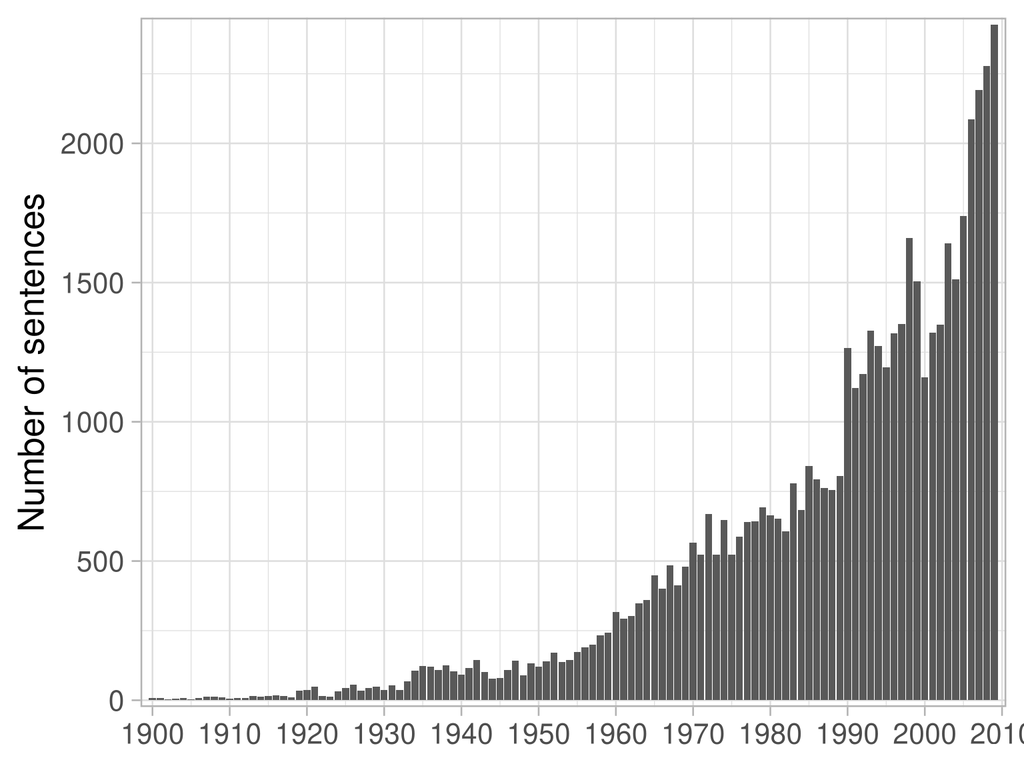

### Closest sentence from ‘rational’ and ‘rationality’ of the backbone community

| Sentence | Title | Year | Journal | Authors | Words Similarity |
| --- | --- | --- | --- | --- | --- |
| Furthermore, our rationality postulate, in conjunction with another condition, is shown to be equivalent to firm choice behavior that can be rationalized in terms of profit maximization. | [Consistent Firm Choice and the Theory of Supply](https://http://www.jstor.org/stable/25055938) | 2005 | Economic Theory | Indraneel Dasgupta | 0.808 |
| The focus of this paper is also limited to arguments for or against rationality as a basis for optimal firm behavior. | [Natural selection, rational economic behavior, and alternative outcomes of the evolutionary process](https://doi.org/10.1016/j.socec.2003.10.001) | 2003 | Journal of Socio Economics | Frank J. | 0.807 |
| In the context of this debate, it becomes very important that a deviation from rationality is first precisely measured at the individual level and then measured again in a market setting to see its ag… | [Is the lure of choice reflected in market prices? Experimental evidence based on the 4-door Monty Hall problem](https://doi.org/10.1016/j.joep.2008.07.004) | 2009 | Journal of Economic Psychology | Siddiqi H. | 0.800 |
| For example, it is often argued that even if there are irrational investors, the ‘marginal investor’ is rational, so that prices must be set rationally. | [Limited attention, information disclosure, and financial reporting](https://doi.org/10.1016/j.jacceco.2003.10.002) | 2003 | Journal of Accounting and Economics | Hirshleifer D. | 0.787 |
| Incentives to be Rational Although the analysis in the previous sub-section shows that irrational agents will survive (under a large set of parameters), this analysis does not indicate whether irratio… | [On the Impossibility of Weak-form Efficient Markets](https://doi.org/10.2307/4126730) | 2003 | Journal of Financial and Quantitative Analysis | Slezak S.L. | 0.786 |
| Russell and Thaler (1985)investigate in a more abstract setup the proportion of rational agents necessary to obtain a “rational” market outcome (cf. | Ricardian equivalence with uninformed consumers? | 1999 | European Journal of Political Economy | Reiter M. | 0.785 |
| Thus, if irrational agents can choose to become rational on the basis of expected return, a mass of irrational investors will persist in equilibrium as long as there is a positive cost associated with… | [On the Impossibility of Weak-form Efficient Markets](https://doi.org/10.2307/4126730) | 2003 | Journal of Financial and Quantitative Analysis | Slezak S.L. | 0.781 |
| Markets cannot be rational if agents are not fully rational in the particular sense in which theorists have modeled it, and this proposition has been uncritically accepted by psychologists and behavio… | [Behavioral economics research and the foundations of economics](https://doi.org/10.1016/j.socec.2004.09.003) | 2005 | Journal of Socio Economics | Smith V. | 0.781 |
| The principles which justify the quantification of rationality at the individual level (linearity, additivity, and no arbitrage opportunities) are the same principles which apply even more forcefully … | [Arbitrage, rationality, and equilibrium](https://doi.org/10.1007/BF00132993) | 1991 | Theory and Decision | Nau R.F. | 0.780 |
| Although I must confess to a traditional view on the central role of rational behavior in finance, I also believe that financial models based on frictionless markets and complete information are often… | [A Simple Model of Capital Market Equilibrium with Incomplete Information](https://http://www.jstor.org/stable/2328367) | 1987 | The Journal of Finance | Robert C. Merton | 0.779 |
| Of course, agents are not rational in all transactions, but we assume that when making irrational decisions, the agent is in fact adjusting his expectation of returns, (although such an adjustment may… | [Impact of speculator’s expectations of returns and time scales of investment on crude oil price behaviors](https://doi.org/10.1016/j.eneco.2008.07.006) | 2009 | Energy Economics | He L.Y. | 0.777 |
| This sophisticated rationality yields results that differ, markedly at times, from behavioral models in which one side of the market has agents who react plausibly, but not rationally, to market condi… | [Quality Uncertainty, Search, and Advertising](https://http://www.jstor.org/stable/1814660) | 1983 | The American Economic Review | Steven N. Wiggins, W. J. Lane | 0.775 |
| The theory of Rational Beliefs (RB due to Kurz, 1994, 1997a) defines a trader to be rational if his model cannot be falsified by the data and if simulated, it reproduces the empirical distribution. | [Beauty contests under private information and diverse beliefs: How different?](https://doi.org/10.1016/j.jmateco.2006.08.001) | 2008 | Journal of Mathematical Economics | Kurz M. | 0.774 |
| Blume and Easley (1990) also address the question of whether rationality alone is a sufficient condition for survival in a financial market, and find this is not the case. | Agent-based computational finance: Suggested readings and early research | 2000 | Journal of Economic Dynamics and Control | LeBaron B. | 0.769 |
| Firstly, only those market participants will be considered who are expected to be the most rational, i.e. | The noise trading approach - Questionnaire evidence from foreign exchange | 1998 | Journal of International Money and Finance | Menkhoff L. | 0.767 |
| concur with their modeling of a rational market maker who correctly infers that certain investors with low valuations are constrained from selling their stock; as the rational market maker refuses to … | [An exploration of earnings whispers forecasts as predictors of stock returns](https://doi.org/10.1108/01443580510631405) | 2005 | Journal of Economic Studies | Abraham R. | 0.767 |
| Not all market participants have to be rational in order for a market to display rational expectations. | [Are Market Forecasts Rational?](https://http://www.jstor.org/stable/1802780) | 1981 | The American Economic Review | Frederic S. Mishkin | 0.766 |
| Profit maximization is not the same thing as rationality because other ends also may be pursued in a rational way. | [Recent Developments in Economics](https://http://www.jstor.org/stable/1884444) | 1954 | The Quarterly Journal of Economics | F. Zeuthen | 0.765 |
| This line of thought underlies, for example, the “partly rational” (i. e. rational asset markets, non-rational goods markets) models of e. g. DORNBUSCH [1976], or BLANCHARD [1981]. | [Learning and Rationality: An Empirical Study of Investment Managers’ Stock Market Predications](https://http://www.jstor.org/stable/20075670) | 1987 | Annales d’Économie et de Statistique | Mark P. Taylor | 0.765 |
| Oliven and Rietz (1995) provide more evidence on how prices can be set in a relatively rational manner while individual traders frequently violate rationality. | Wishes, expectations and actions: A survey on price formation in election stock markets | 1999 | Journal of Economic Behavior and Organization | Forsythe R. | 0.763 |

### Closest sentences of the backbone community’s centroid

Sentence

Title

Year

Journal

Authors

Similarity to Backbone Centroid

2. shows that the equilibrium price depends on the conjunction of traders’ budgets and beliefs rather than on their beliefs alone.

[Interpreting the predictions of prediction markets](https://doi.org/10.1016/j.econlet.2006.01.004)

2006

Economics Letters

Manski C.

0.796

The price ought then to reflect the information that the market learns, weakening the importance of this arbitrage by managers.21 Generalizing the previous results to handle more than two types of securities is also straightforward.

[Interest Rates, Inflation, and Corporate Financial Policy](https://http://www.jstor.org/stable/2534339)

1982

Brookings Papers on Economic Activity

Roger H. Gordon, John B. Shoven

0.796

A competing model to the one discussed here is one in which investors are only one of two types: informed, and uninformed who glean some knowledge by conditioning their beliefs on price (see, for example, Grossman and Stiglitz, 1980; Demski and Feltham, 1994).

Essays on disclosure

2001

Journal of Accounting and Economics

Verrecchia R.E.

0.791

Hillmer and Yu, on the other hand, note that the incorporation of information into prices “cannot be completed instantaneously” because “…in practice an investor will not react…unless he is convinced that it is economically advantageous.” (p. 321).

[Evidence on the speed of convergence to market efficiency](https://doi.org/10.1016/j.jfineco.2004.06.004)

2005

Journal of Financial Economics

Chordia T.

0.787

However, the qualitative conclusion that more heterogeneity of beliefs leads to greater deviations of prices from traders’ fundamental valuations would be robust.2 The pricing scheme p* characterized in Theorem 2 is not the only one satisfying equation (7): there exists in addition a continuum of pricing schemes with a “Ponzi scheme” added on top of the “minimal pricing scheme” [Harrison and Kreps 1978].

[Speculative Investor Behavior and Learning](https://http://www.jstor.org/stable/2946709)

1996

The Quarterly Journal of Economics

Stephen Morris

0.782

For example, it is often argued that even if there are irrational investors, the ‘marginal investor’ is rational, so that prices must be set rationally.

[Limited attention, information disclosure, and financial reporting](https://doi.org/10.1016/j.jacceco.2003.10.002)

2003

Journal of Accounting and Economics

Hirshleifer D.

0.781

Therefore, in an economy with asymmetric information, the price of an asset today will not equal the representative agent’s discounted expected value of the asset’s payoff stream conditional on information available today, but the price will also encompass investors’ higher-order beliefs (see also, ).

[How equilibrium prices reveal information in a time series model with disparately informed, competitive traders](https://doi.org/10.1016/j.jet.2007.01.011)

2007

Journal of Economic Theory

Walker T.B.

0.779

This section examines this possibility by looking at the determinants of pricing errors.

[Tests of alternate models for the pricing of Korean Treasury bond futures contracts](https://doi.org/10.1016/j.pacfin.2006.01.005)

2006

Pacific Basin Finance Journal

Kang J.

0.778

A noise in the price of the stock in the market makes things more complicated for managers, but will lead to the existence of an optimal equilibrium for both parties, thus justifying the hypothesis (1).

[Information asymmetry, contract design and process of negotiation: The stock options awarding case](https://doi.org/10.1016/j.jcorpfin.2008.01.001)

2008

Journal of Corporate Finance

de La Bruslerie H.

0.778

(in press) address this question of whether the induced rationality from an arbitraged market could spill over to a second nonmarket choice that would otherwise promote preference reversals.

A behavioral mindset on environment policy

2002

Journal of Socio Economics

Shogren J.F.

0.777

The driving element of this result is the competition between informed traders.

[Duration, volume and volatility impact of trades](https://doi.org/10.1016/j.finmar.2005.06.002)

2005

Journal of Financial Markets

Manganelli S.

0.777

This hints at a more general conjecture that the market mechanisms and the market structure are perhaps of greater importance than whether or not the agents are in fact using optimal trading strategies that take into account all of the relevant market signals.

[On the disequilibrium dynamics of sequential monetary economies](https://doi.org/10.1016/j.jebo.2008.06.008)

2008

Journal of Economic Behavior and Organization

van der Hoog S.

0.776

This theory relies on the assumption that the influence of rational agents, who seek to discover the ‘true’, fundamental value of a stock, outweighs that of noise traders and anchors the price to its rational value.

[Self-referential behaviour, overreaction and conventions in financial markets](https://doi.org/10.1016/j.jebo.2004.11.016)

2007

Journal of Economic Behavior and Organization

Wyart M.

0.775

When deciding on the quantity he associates with each realized price, the investor asks himself, “If that is the realized price, what would it tell me about what the informed investors have learned?” In this way, the uninformed investor can use information contained in prices to free-ride on what others have learned.

[Ratings shopping and asset complexity: A theory of ratings inflation](https://doi.org/10.1016/j.jmoneco.2009.04.006)

2009

Journal of Monetary Economics

Skreta V.

0.774

In a richer setting with many possible quantities, the informed trader’s relative presence across different quantities continues to make some quantities worse value than other quantities for the uninformed investors.

[You can’t always get what you want: Trade-size clustering and quantity choice in liquidity](https://doi.org/10.1016/j.jfineco.2004.10.007)

2005

Journal of Financial Economics

Moulton P.

0.772

### Closest sentences of each HDBSCAN cluster’s centroid composing the backbone community

| Sentence | Title | Year | Journal | Authors | Similarity to HDSBSCAN Centroid |
| --- | --- | --- | --- | --- | --- |
| The notion of a normal price derived from such analysis still survives, but it is not easy to be certain that the notion plays any very significant part in our actual thinking. | [The Content of the Value Concept](https://http://www.jstor.org/stable/1884043) | 1917 | The Quarterly Journal of Economics | Abbott Payson Usher | 0.682 |
| The proposition that the price-level is the passive resultant of the other factors is fundamental to the causal theory accompanying the equation of exchange, and a disproof of the proposition on its o… | [Social Value and the Theory of Money](https://http://www.jstor.org/stable/1823155) | 1917 | Journal of Political Economy | Walter Stewart | 0.678 |
| It appears, therefore, that the theory of prices is not to be dispensed with in a full explanation of social distribution; and this theory of prices is based on individual values. | [On the Concept of Social Value](https://http://www.jstor.org/stable/1882798) | 1909 | The Quarterly Journal of Economics | Joseph Schumpeter | 0.675 |
| VII The reader will observe that in the present discussion no such fundamental opposition is found between prices based upon cost on the one hand, and differential prices on the other, as is ordinaril… | [The Theory of Differential Rates](https://http://www.jstor.org/stable/1884239) | 1916 | The Quarterly Journal of Economics | G. P. Watkins | 0.673 |
| To my mind, the following propositions contain the essence of the theory of prices, on which the causes must be based. | [Causes of the Changes in Prices Since 1896](https://http://www.jstor.org/stable/1814912) | 1911 | The American Economic Review | J. Laurence Laughlin | 0.660 |
| He does not, of course, profess to show what the market prices will be ;48 but he does demonstrate more adequately than any other type of economist the complex inter-relationships logically involved i… | [The Role of Money in Economic Theory](https://http://www.jstor.org/stable/1803798) | 1916 | The American Economic Review | Wesley C. Mitchell | 0.655 |
| He does not think, however, that price fixing on ” the basis described is the same as that which would obtain if normal forces were working under normal conditions.” | [Price Fixing and the Theory of Profit](https://http://www.jstor.org/stable/1884491) | 1919 | The Quarterly Journal of Economics | Kemper Simpson | 0.651 |
| To the objection that markets are seldom perfectly adjusted, the reply may be made that price-fixing boards are seldom omniscient, and those that are omniscient are seldom perfectly free from bias, pr… | [The Possibilities of Price Fixing in Time of Peace](https://http://www.jstor.org/stable/1814003) | 1919 | The American Economic Review | T. N. Carver | 0.648 |
| ’ But in another, as though in doubt of such a wide statement, he again says: ” But while market price must always measure the utility of the commodity to the last purchaser, that is, the person to wh… | [Trusts, the Marginal Producer and Prices](https://http://www.jstor.org/stable/1817481) | 1900 | Journal of Political Economy | Frank L. McVey | 0.644 |
| The orthodox economist stating this familiar doctrine would not be put off by the affirmation that a great part of the cost was indeterminate, being joint for all the products in large part; that it i… | [Contributions to the Theory of Railway Rates.-IV](https://http://www.jstor.org/stable/2222136) | 1913 | The Economic Journal | F. Y. Edgeworth | 0.642 |

| Sentence | Title | Year | Journal | Authors | Similarity to HDSBSCAN Centroid |
| --- | --- | --- | --- | --- | --- |
| But the acceptance of this explanation implies an acceptance of the corollary that, inasmuch as preliminary restriction of consumption is required, capital formation must proceed at a less rapid rate … | [Commercial Banking and Capital Formation: IV](https://http://www.jstor.org/stable/1822000) | 1918 | Journal of Political Economy | H. G. Moulton | 0.635 |
| It is fundamental to the conception of the capitalization theory, however, that these impulses from the money market are not, as they superficially appear, primary or causal in a theory of interest, i… | [Interest Theories, Old and New](https://http://www.jstor.org/stable/1804984) | 1914 | The American Economic Review | Frank A. Fetter | 0.621 |
| Nor can it be inferred that such government intended to deny the application of economic laws to valuation of increments earned or unearned, while insisting upon the usual results thereof in the case … | [Valuation of Public Service Corporations](https://www.jstor.org/stable/10.2307/3000031) | 1910 | American Economic Association Quarterly | W. H. Williams | 0.568 |
| It is at least thinkable that our present knowledge2 of the ways and means in which to secure economic results from time-consuming processes might not prove adequate to employ the constantly increasin… | [Commercial Banking and Capital Formation: A Criticism](https://http://www.jstor.org/stable/1822123) | 1919 | Journal of Political Economy | Myron W. Watkins, H. G. Moulton | 0.567 |
| So important is the latter factor, I hold, that if all investment should be judiciously made, and if it turned out ultimately that there had been no wasting of capital or overcrowding of particular in… | [Promotion as the Cause of Crises](https://http://www.jstor.org/stable/1883307) | 1915 | The Quarterly Journal of Economics | Minnie Throop England | 0.547 |
| This -disease would not be what it is if the striving for an advantageous investment of capital were accompanied by a proper insight into the facts of the case, an adequate appreciation of the causes … | [On Some Unsettled Questions of Public Credit](https://http://www.jstor.org/stable/2221279) | 1906 | The Economic Journal | Gustav Cohn | 0.540 |
| Accepting an arbitrary charge for depreciation as a good asset in the cost of manufactured goods, the logic seems unavodiable that there is no greater objection to an arbitrary charge for interest. | [Interest on Investment as a Factor in Manufacturing Costs](https://http://www.jstor.org/stable/1813979) | 1919 | The American Economic Review | Clinton H. Scovell, C.P.A. | 0.534 |
| On the consequences of leaving the agents with less than a fair return on the requisite capital it is unnecessary to dwell; there would cease to be agents-a condition of things which has not arisen si… | [The Monopoly in Alcoholic Drink](https://http://www.jstor.org/stable/2959904) | 1919 | The Economic Journal | J. S. Eagles | 0.534 |
| Thus the formula as to the “continuance” of house and of capital rests not upon the solid basis of literally and unmistakably identical facts, but upon fluctuating subjective points of view. | [The Nature of Capital: A Rejoinder](https://http://www.jstor.org/stable/1883349) | 1907 | The Quarterly Journal of Economics | E. Böhm-Bawerk | 0.531 |
| And unless Mr. Watkins can show that in practice new capital can profitably be created in the absence of expanding consumption his theoretical statement in worthless.” | [Commercial Banking and Capital Formation: A Criticism](https://http://www.jstor.org/stable/1822123) | 1919 | Journal of Political Economy | Myron W. Watkins, H. G. Moulton | 0.529 |

| Sentence | Title | Year | Journal | Authors | Similarity to HDSBSCAN Centroid |
| --- | --- | --- | --- | --- | --- |
| In all these matters the responsible managers of business enterprises occasionally forget that, even if the public is somewhat prejudiced-and dealers are not the best judges on this point-what is bad … | [A Third Factor in the Variation of Productivity: The Load Factor](https://http://www.jstor.org/stable/1809629) | 1915 | The American Economic Review | G. P. Watkins | 0.576 |
| If, however, it turns out that enterprise is really entitled to rank as the equal of the other productive forces,- land, labor, and capital,- its exact nature can hardly be a matter of indifference. | [Enterprise and Profit](https://http://www.jstor.org/stable/1885862) | 1900 | The Quarterly Journal of Economics | Frederick B. Hawley | 0.543 |
| one reaso’n why the ” theory of business,” leads a, ” life of obstruction ” is becausse the ” men of business” will ” not reason out thle theories ” Economics.furnishes a moeals for curing this defect… | [Economics and Commercial Education](https://http://www.jstor.org/stable/2957411) | 1901 | The Economic Journal | L. L. Price | 0.543 |
| Perhaps the chief difference between the viewpoints of business and pure theory is that the business man is less indifferent toward the grounds of choice than the theorist. | [The Role of Money in Economic Theory](https://http://www.jstor.org/stable/1803798) | 1916 | The American Economic Review | Wesley C. Mitchell | 0.528 |
| Still, it has drawbacks from the producer’s point of view, and he feels the need of protection and support by and from those who understand his position and its difficulties: hence the comparatively n… | [Auctioneers and Auctions](https://http://www.jstor.org/stable/2220608) | 1910 | The Economic Journal | H. Wilfred Plumridge | 0.517 |
| The circumlistance that the affairs which will occupy the minds of businessmen in after-life, will be concrete and actual, renders it more probable that without that preliminary mental disciplille whi… | [Economics and Commercial Education](https://http://www.jstor.org/stable/2957411) | 1901 | The Economic Journal | L. L. Price | 0.509 |
| This belief is, however, a premise of business activity and of accountancy. | [Social Value and the Theory of Money](https://http://www.jstor.org/stable/1823155) | 1917 | Journal of Political Economy | Walter Stewart | 0.502 |
| You must assume that the managers and foremen or forewomen want to do the right thing; you must assume that if apparently obvious reforms are not made at once there are difficulties in the way, to be … | [The Task of the Welfare Supervisor](https://http://www.jstor.org/stable/2221845) | 1916 | The Economic Journal | W. J. Ashley | 0.496 |
| ments of profit and loss, financial statements, and bank balances comprise the cold logic that sways the judgment of captains of industry. | [The Economic Function of the Common Law](https://http://www.jstor.org/stable/1820903) | 1918 | Journal of Political Economy | Homer Hoyt | 0.494 |
| The broad idea can be filled in with various detail; but, while we should agree that the manufacturer or trader must not let his imagination run away with his discretion, we should also probably allow… | [The Practical Aspects of Economic](https://http://www.jstor.org/stable/2221425) | 1909 | The Economic Journal | L. L. Price | 0.494 |

| Sentence | Title | Year | Journal | Authors | Similarity to HDSBSCAN Centroid |
| --- | --- | --- | --- | --- | --- |
| This has led some economists to maintain that there is a degree of indeterminancy to market price. | [Market Price Analysis](https://http://www.jstor.org/stable/1230332) | 1924 | Journal of Farm Economics | Warren C. Waite | 0.665 |
| That a theory in conflict with these facts found such ready acceptance may be explained by the fascination of the rationality of the system of prices, which the general law of variable proportion woul… | [Economic Theory](https://http://www.jstor.org/stable/1814854) | 1926 | The American Economic Review | G. A. Kleene, Richard S. Meriam, Sumner H. Slichter, Raymond T. Bye, A. B. Wolfe, John P. Frey | 0.664 |
| A MODIFICATION OF THE ASSUMPTIONS We may now modify our assumptions and bring them closer to reality by introducing certain factors which may operate to disturb the price level. | [The Theory of Hedging](https://http://www.jstor.org/stable/1822306) | 1923 | Journal of Political Economy | Charles O. Hardy, Leverett S. Lyon | 0.638 |
| For at the same time he asserts that “we cannot expect this test to be fulfilled when there are violent changes in the quantities [and prices] which enter from time to time into the computation.” | [Professor Edgeworth’s View on Index-Numbers](https://http://www.jstor.org/stable/1882334) | 1924 | The Quarterly Journal of Economics | C. M. Walsh | 0.631 |
| An expected change of prices causes prices to change at once: it is not in the least necessary that the public should have clear or correct opinions about the cause of the rise, but only that they sho… | [Annual Meeting of the Royal Economic Society: Discussion on Monetary Reform](https://http://www.jstor.org/stable/2223157) | 1924 | The Economic Journal | NA | 0.627 |
| Consider the reasoning involved in reaching the usual conclusion from an expected change in demand and supply conditions. | [Practical Applications of Correlation Studies of Prices](https://http://www.jstor.org/stable/1229874) | 1926 | Journal of Farm Economics | Holbrook Working | 0.623 |
| “7 No clear solution is volunteered by the witnesses, although the inference is made that a stable price index is utterly impracticable when sharp fluctuations of some component group of prices occur. | [The 1928 Hearings on the Strong Bill](https://http://www.jstor.org/stable/1824410) | 1929 | Journal of Political Economy | L. D. Edie | 0.620 |
| so that it is not necessary to retain the assumption of an unchanging demand. | [Statistical Analyses and the “Laws” of Price](https://http://www.jstor.org/stable/1884046) | 1928 | The Quarterly Journal of Economics | Mordecai Ezekiel | 0.612 |
| And even if we decide on other grounds that the price level should normally be kept stable, we shall probably admit that either an exception ought to be made, or else that money contracts ought to be … | [Some Aspects of the Stable Money Question](https://http://www.jstor.org/stable/1882963) | 1929 | The Quarterly Journal of Economics | Frederick A. Bradford | 0.611 |
| The caution mentioned earlier, that more exact knowledge of the effects of supplies upon price and of prices upon consumption might materially modify the conclusions, applies with equal force here. | [A Statistical Examination of the Problem of Handling Annual Surpluses of Non-Perishable Farm Products](https://http://www.jstor.org/stable/1230429) | 1929 | Journal of Farm Economics | Mordecai Ezekiel | 0.605 |

| Sentence | Title | Year | Journal | Authors | Similarity to HDSBSCAN Centroid |
| --- | --- | --- | --- | --- | --- |
| he theory that business profits, in the long run, tend towards equality between different industries is qualified by the admission that, at any given time, variations exist. | [Industrial Profits in 1917](https://http://www.jstor.org/stable/1884874) | 1925 | The Quarterly Journal of Economics | Ralph C. Epstein | 0.542 |
| It must again be emphasized, however, that this result does not flow from the assumption that each seeks independently to maximize his profit. | [Duopoly: Value Where Sellers are Few](https://http://www.jstor.org/stable/1885441) | 1929 | The Quarterly Journal of Economics | E. H. C. | 0.536 |
| Hitherto the chief emphasis has been placed on the factual instability of wants and their liability to be changed as well as satisfied by business activity. | [Ethics and the Economic Interpretation](https://http://www.jstor.org/stable/1886033) | 1922 | The Quarterly Journal of Economics | Frank H. Knight | 0.533 |
| His decisions are made from the point of view of the probable movement of demand, which lies beyond his control, and from the point of view of the efficiency of his own organization, which he is capab… | [A Moving Equilibrium of Demand and Supply](https://http://www.jstor.org/stable/1882433) | 1925 | The Quarterly Journal of Economics | Henry Ludwell Moore | 0.527 |
| In this case the production cannot decrease, for, under rational management no single factor would be used to the extent of its being a detriment. | [Graphical Presentation of Thuenen’s Theory of Intensity](https://http://www.jstor.org/stable/1229926) | 1928 | Journal of Farm Economics | Richard Krzymowski, P. G. Minneman | 0.525 |
| In the first place, we may question whether the anticipation of unusual profits is not in itself a vital element in the incentive to business activity. | [Cost of Production and Price over Long and Short Periods](https://http://www.jstor.org/stable/1822518) | 1921 | Journal of Political Economy | F. H. Knight | 0.523 |
| Indeed, if there were less opportunity to make a profit through the working-out of certain valuations or through financial manipulation of accounts, there would need to be more attention given to poss… | [Problems of Public-Utility Rate Regulation and Fair Return](https://http://www.jstor.org/stable/1822365) | 1924 | Journal of Political Economy | C. O. Ruggles | 0.521 |
| But if there is any truth in the theory that pecuniary rewards are among the motives to industrial policy, which even the most protestant of economists does not deny, it will cause business executives… | [A Theory of the Rate of Wages](https://http://www.jstor.org/stable/1884753) | 1922 | The Quarterly Journal of Economics | Walton H. Hamilton | 0.518 |
| upon a more complete knowledge of the essential facts and designed to give more stability to production. | [Research Problems Involved in Providing Continuous Economic Information to Farmers](https://http://www.jstor.org/stable/1230498) | 1929 | Journal of Farm Economics | Jesse W. Tapp | 0.513 |
| Whether such variations from the typical are justified from the standpoint of profits is a matter which must be based on a careful analysis of existing conditions. | [Some Salient Features in Farm Organization](https://http://www.jstor.org/stable/20171667) | 1920 | Journal of Farm Economics | W. F. Handschin | 0.509 |

Sentence

Title

Year

Journal

Authors

Similarity to HDSBSCAN Centroid

Where contingent voting issues fail to conform to the foregoing requirements, the presumption is raised that they may be designed to maintain voting control in the hands of the active management of the corporation, tho perhaps to a lesser extent than is true in the case of the non-voting issu

[Stockholders’ Voting Rights and the Centralization of Voting Control](https://http://www.jstor.org/stable/1885170)

1926

The Quarterly Journal of Economics

W. H. S. Stevens

0.660

If the contingent control of a class of stock, therefore, is made sufficiently strong, it may perhaps be conceded that the issue might otherwise be of a very limited voting power or perhaps even completely non voting.

[Stockholders’ Voting Rights and the Centralization of Voting Control](https://http://www.jstor.org/stable/1885170)

1926

The Quarterly Journal of Economics

W. H. S. Stevens

0.642

VWill the distorting influence of a greatly augmented stake to be won by practical politics be less distorting than the influence of profits?

[The Webbs’ Constitution for the Socialist Commonwealth](https://http://www.jstor.org/stable/1828035)

1921

The American Economic Review

John R. Commons

0.623

That the fixing of the amount of going value is almost entirely speculative and arbitrary is concretely shown by the conclusions of one of the ablest minds in the field of regulation.

[Some Aspects of the Going-Value Concept in Utility Valuation](https://http://www.jstor.org/stable/3138651)

1925

The Journal of Land & Public Utility Economics

Martin G. Glaeser

0.605

An investment that paid sometimes i per cent and sometimes 7 per cent, with equal probability, would not be valued as highly as one that could be relied upon

[Analysis of Profit](https://http://www.jstor.org/stable/1823083)

1925

Journal of Political Economy

R. A. Lehfeldt

0.601

8. If investors acted rationally, there might not be uneconomical construction under reproduction cost.

[Railroad Valuation Again: A Rejoinder](https://http://www.jstor.org/stable/1820652)

1926

Journal of Political Economy

John Bauer

0.597

The practical difficulties involved (e.g., the determination of the amount of capital to be included in any case and the selection of a rate) have no doubt weighed most heavily in establishing this attitude, but the theoretic objections to the doctrine are clear-cut and convincing.

[Interest During Construction](https://http://www.jstor.org/stable/1822214)

1920

Journal of Political Economy

W. A. Paton

0.585

So far, however, is this assumption from being true, that one’s whole attitude toward the relation between stock speculation and the money market undergoes a decided change when the differences in velocities are known.

[The Effect of Stock Speculation on the New York Money Market](https://http://www.jstor.org/stable/1885173)

1926

The Quarterly Journal of Economics

James Harvey Rogers

0.585

The decision thus rests on the issue whether or not the distribution of stock to the stockholders, rather than of cash, is to them a realiza?

[Are Stock Dividends Income?](https://http://www.jstor.org/stable/1821033)

1920

Journal of Political Economy

T. David Zukerman

0.581

In the following discussion of these two issues, particular attention will be given to the propriety of using undepreciated investment as a rate base.

[Undepreciated Investment as a Utility Rate Base](https://http://www.jstor.org/stable/3138894)

1925

The Journal of Land & Public Utility Economics

George C. Mathews

0.579

| Sentence | Title | Year | Journal | Authors | Similarity to HDSBSCAN Centroid |
| --- | --- | --- | --- | --- | --- |
| a given chaiige in the price ratio will cause a given change in the relative quantities demanded, whichever of the two prices has moved relatively to the other) this is by no means the case when the l… | [Market Imperfection and Excess Capacity](https://http://www.jstor.org/stable/2549105) | 1935 | Economica | Nicholas Kaldor | 0.709 |
| While in the foregoing paragraphs the voluntary exchange assumption in general was rejected as highly unrealistic, the present discussion is concluded with an analogous objection to the more specific … | [The Voluntary Exchange Theory of Public Economy](https://http://www.jstor.org/stable/1882886) | 1939 | The Quarterly Journal of Economics | Richard Abel Musgrave | 0.702 |
| A theory of prices which will be competent to explain why any particular combination is adopted must at least abandon the | [MARX AS A PURE ECONOMIST](https://www.jstor.org/stable/10.2307/45366557) | 1939 | Economic History | Henry Smith | 0.693 |
| From many sources one repeatedly gets the impression that one of the fundamental assumptions, popularly, at least, is that price-parity is a desirable objective. | [Validity of the Fundamental Assumptions Underlying Agricultural Adjustment](https://http://www.jstor.org/stable/1231309) | 1936 | Journal of Farm Economics | M. L. Wilson, O. B. Jesness, G. F. Warren, J. S. Davis, O. C. Stine, H. E. Erdman, J. D. Black, Don S. Anderson | 0.692 |
| For instance, under oligopoly, if A acted irrationally or (relaxing our assumption (ix)) altruistically, by reducing price, B would be forced immediately to follow his price policy. | [The Nature of Aggressive Selling](https://http://www.jstor.org/stable/2548609) | 1935 | Economica | W. H. Hutt | 0.689 |
| He demonstrates that its use is based on the assumption (tacit rather than explicit) that price-movements are compensatory in character. | [Menger on Money](https://http://www.jstor.org/stable/2549251) | 1936 | Economica | Erich Roll | 0.689 |
| In addition to this “rational” selection of rigid prices there are certain influences contributing to price rigidity which are not a part of any desire to maximize profits either in the short or long … | [Monopoly Power and Price Rigidities](https://http://www.jstor.org/stable/1882612) | 1936 | The Quarterly Journal of Economics | J. K. Galbraith | 0.686 |
| price levels;“, and it may fairly be argued that he should not preclude by assumption the possibility of relative changes at this point. | [An Examination of Mr. Keynes’s Price-Level Concepts](https://http://www.jstor.org/stable/1824028) | 1933 | Journal of Political Economy | Albert G. Hart | 0.684 |
| The reasoning behind this view is sometimes no more elaborate than an assumption that prices must change with changing conditions of demand and supply, and that the penalty of price resistance to such… | [Public Utility Prices and the Business Cycle: A Study in the Theory of Price Rigidity](https://http://www.jstor.org/stable/1928401) | 1939 | The Review of Economics and Statistics | John D. Sumner | 0.682 |
| In other words, we shall examine changes in the level of prices not in comparison with some previously existing price level, but in comparison with a price level that would obtain if each seller were … | [Changes in the Price Level under the Influence of Maladjustment of Supply and Demand](https://http://www.jstor.org/stable/2548651) | 1937 | Economica | Wl. Zawadzki | 0.677 |

| Sentence | Title | Year | Journal | Authors | Similarity to HDSBSCAN Centroid |
| --- | --- | --- | --- | --- | --- |
| There are, however, reasons for believing in the interpretation given” and then it seems that a better explanation of investment is possible than the poor one yielded by the acceleration principle. | [Statistical Evidence on the Acceleration Principle](https://http://www.jstor.org/stable/2549019) | 1938 | Economica | J. Tinbergen | 0.717 |
| On the face of it, there must be plausible reasons for holding that the use of more capital is equivalent to the use of more time in production; otherwise the doctrine would not have been so generally… | [Professor Hayek and the Theory of Investment](https://http://www.jstor.org/stable/2224581) | 1935 | The Economic Journal | Frank H. Knight | 0.669 |
| It might be argued that since different forms of investment involve different costs the choice is not so simply determined. | [Fluctuations in Capital and the Demand for Money](https://http://www.jstor.org/stable/2967549) | 1934 | The Review of Economic Studies | S. P. Chambers | 0.656 |
| When this view is accepted as a working hypothesis, reasoning about interest assumes greater elasticity. | [Developments in Economic Theory](https://http://www.jstor.org/stable/1807775) | 1936 | The American Economic Review | Emil Lederer | 0.647 |
| recognised the much more fundamental fact that such constancy of the value dimension has no necessary connection with the reasons why we wish to ” maintain capital intact,” and that in consequence the… | [The Maintenance of Capital](https://http://www.jstor.org/stable/2548607) | 1935 | Economica | F. A. von Hayek | 0.645 |
| My argument does not condemn all analyses of the cycle that run in terms of the multiplicative effects of investment upon income or of the repercussions of changes in income upon expectation and inves… | [A Note on the Multiplier](https://http://www.jstor.org/stable/2967539) | 1938 | The Review of Economic Studies | E. S. Shaw | 0.638 |
| But these considerations do not call for any essential modification of the basic general theory.2’ The importance even of provision for possible real disinvestment, i.e., actual consumption of capital… | [The Quantity of Capital and the Rate of Interest: I](https://http://www.jstor.org/stable/1823196) | 1936 | Journal of Political Economy | Frank H. Knight | 0.634 |
| The one other point that stands out clearly from all the analysis is that under dynamic conditions there is a considerable indeterminacy in the relationship of investment to existing prices and quanti… | [The Rate of Interest](https://http://www.jstor.org/stable/1804485) | 1938 | The American Economic Review | Richard M. Bissell, Jr. | 0.633 |
| Even accepting at its face value the validity of the relationship which the acceleration principle is supposed to express, it turns out to be a long-period theory of investment. | [The Rate of Interest](https://http://www.jstor.org/stable/1804485) | 1938 | The American Economic Review | Richard M. Bissell, Jr. | 0.631 |
| It is not difficult to see how Professor Knight’s habit of thinking not only of capital in the abstract but even of particular capital goods as permanent has led him to his peculiar conclusion. | [The Mythology of Capital](https://http://www.jstor.org/stable/1885022) | 1936 | The Quarterly Journal of Economics | F. A. v. Hayek | 0.628 |

| Sentence | Title | Year | Journal | Authors | Similarity to HDSBSCAN Centroid |
| --- | --- | --- | --- | --- | --- |
| These explanations assume that the business man will not behave rationally, that his behavior does not follow the same rules which it is supposed to follow in the theoretical system of economics. | [Equilibrium Economics and Business-Cycle Theory](https://http://www.jstor.org/stable/1885790) | 1930 | The Quarterly Journal of Economics | Simon Kuznets | 0.603 |
| In particular, I find no recognition of the crucial fact that profit in the strict sense of a divergence (either positive or negative) between results and anticipations is the “natural” method of brin… | [Barbara Wootton on Economic Planning](https://http://www.jstor.org/stable/1824552) | 1935 | Journal of Political Economy | Frank H. Knight | 0.592 |
| Among the assumptions should be also those much-talked-of “error-types,” that is to say, assumptions of behavior-types which do not conform to the principle of profit maximization. | [Evaluation of the Practical Significance of the Theory of Monopolistic Competition](https://http://www.jstor.org/stable/1803621) | 1939 | The American Economic Review | Fritz Machlup | 0.580 |
| Whatever be the points of debate among economic theorists about the origin of profits, certain it is that, for individual enterprise, the maintenance of net earnings depends at least partly upon the a… | [The Commercial Application of Forecasting Methods](https://http://www.jstor.org/stable/1230356) | 1930 | Journal of Farm Economics | Donald R. G. Cowan | 0.575 |
| The theory does not require a very high degree of “rationality” from a competitive entrepreneur. | [A Note on Fixed Costs](https://http://www.jstor.org/stable/1882827) | 1934 | The Quarterly Journal of Economics | Fritz Machlup | 0.572 |
| or others adjusting their purchases for maximum profit, in such a way that their purchases could be increased without effective limit if they should lead to sufficiently increased profits. | [Demand Functions with Limited Budgets](https://http://www.jstor.org/stable/1907346) | 1935 | Econometrica | Harold Hotelling | 0.566 |
| Some decisions require the greatest possible knowledge of the detailed operation of the firm itself, others require the greatest possible knowledge of the probable actions of other producers, of the t… | [The Problem of Management and the Size of Firms](https://http://www.jstor.org/stable/2224765) | 1934 | The Economic Journal | Austin Robinson | 0.565 |
| The assumption that an attempt is made to maximise total profits is probably much more realistic. | [Some Notes on Monopoly Price](https://http://www.jstor.org/stable/2967577) | 1937 | The Review of Economic Studies | R. H. Coase | 0.565 |
| More specifically, it is assumed that business men do not increase or decrease the current employment of the factors of production in anticipation of the higher price level or the higher expense level… | [Public Expenditure, Prices, and the National Income](https://http://www.jstor.org/stable/1053194) | 1936 | Southern Economic Journal | E. M. Bernstein | 0.564 |
| In the second place, if anticipations are recognized as the driving forces of business enterprise, it must be accepted that these driving forces are not in themselves observables. | [Anticipations, Business Planning, and the Cycle](https://http://www.jstor.org/stable/1882089) | 1937 | The Quarterly Journal of Economics | Albert Gailord Hart | 0.564 |

| Sentence | Title | Year | Journal | Authors | Similarity to HDSBSCAN Centroid |
| --- | --- | --- | --- | --- | --- |
| But unless we go so far as to assume that a system of free competition fully does away with irrationality and inertia, we shall have to admit that flexibility and free competition are not the same thi… | [Money and Production](https://http://www.jstor.org/stable/1822998) | 1935 | Journal of Political Economy | Walter Egle | 0.659 |
| But it is important to remember that such an assumption is something quite different and logically much less satisfactory in the case of imperfect competition than in the case of perfect competition. | [Mrs. Robinson’s “Economics of Imperfect Competition”](https://http://www.jstor.org/stable/2548808) | 1934 | Economica | Nicholas Kaldor | 0.628 |
| There is, of course, no more reason to expect that the extent of variation which comes into existence is automatically restricted by competition to the ideal amount, than there is to suppose that comp… | [Monopolistic Competition and Public Policy](https://http://www.jstor.org/stable/1807766) | 1936 | The American Economic Review | Donald H. Wallace | 0.616 |
| By the same token I had believed that a description of the factors which do affect price in any actual competitive situation (including any monopolistic elements which may be present) was not a defens… | [Public Policy and Discriminatory Prices of Steel: A Reply to Professor Fetter](https://http://www.jstor.org/stable/1824780) | 1938 | Journal of Political Economy | Melvin G. De Chazeau | 0.604 |
| But the element of indeterminateness, which the isolating assumption of perfect competition enabled us to detect, still continues in force when the basic assumption is removed. | [The Equilibrium of the Firm](https://http://www.jstor.org/stable/2224727) | 1934 | The Economic Journal | Nicholas Kaldor | 0.602 |
| Looking beyond his work, taking into consideration certain additional elements of competition, we may still expect to find duopoly prices usually uniform; but the assumption that the prices of two com… | [Edgeworth’s Theory of Duopoly Price](https://http://www.jstor.org/stable/2224579) | 1935 | The Economic Journal | A. J. Nichol | 0.589 |
| The old principle gave way to the new when it became clear that unless some rather unusual technical conditions prevailed 1 these three conditions were mutually incompatible, that the first two were m… | [Theory and Practice in Socialist Economics](https://http://www.jstor.org/stable/2967541) | 1938 | The Review of Economic Studies | A. P. Lerner | 0.583 |
| To reproduce the conditions of perfect competition ” is not the correct battle-cry for this type of ” rationalisation,” unless perfect competition is the rule over the main part of the field of indust… | [Some Notes on Ideal Output](https://http://www.jstor.org/stable/2224577) | 1935 | The Economic Journal | R. F. Kahn | 0.582 |
| On the one hand, it is obvious that certain parts of a complete program of flexibility, implied in the term “perfect” competition,6 belong in the field of abstraction and hypothesis. | [The “Monetary” Conditions of Economic Stability](https://http://www.jstor.org/stable/1803728) | 1938 | The American Economic Review | Walter Egle | 0.577 |
| But even this conclusion is made less certain by complexities arising from the possibility that these competitive relationships may not be autonomous. | [The Relation of Commodities in Demand](https://http://www.jstor.org/stable/1803729) | 1938 | The American Economic Review | E. E. Lewis | 0.577 |

| Sentence | Title | Year | Journal | Authors | Similarity to HDSBSCAN Centroid |
| --- | --- | --- | --- | --- | --- |
| As has already been said, where investment decisions are based on subjective judgments of the relative values of different things and not objective comparison of their values expressed in some common … | [Investment Policy in a Nationalised Industry](https://http://www.jstor.org/stable/2296277) | 1949 | The Review of Economic Studies | M. F. Scott | 0.687 |
| This criterion, which should take precedence over the Marginal Rule, would tend to foster efficiency and economy in management, would give some guide to investment policy even if slightly incorrect an… | [Price and Outlay Policy of State Enterprise](https://http://www.jstor.org/stable/2226038) | 1945 | The Economic Journal | T. Wilson | 0.646 |
| It means that two investments will be considered equally attractive, provided they have the same focus-gain and -loss whatever the shape of the two potential surprise functions at other points.1 The f… | [Three Notes on “Expectation in Economics”](https://http://www.jstor.org/stable/2549588) | 1949 | Economica | Ralph Turvey, J. de V. Graaff, W. Baumol, G. L. S. Shackle | 0.616 |
| On what principle will he then make his choice of assets, and what actually-observed market phenomena can be accounted for by supposing that all or many individuals make use of this principle? | [An Analysis of Speculative Choice](https://http://www.jstor.org/stable/2550246) | 1945 | Economica | G. L. S. Shackle | 0.615 |
| The significance of this proposition in a discussion of investment decisions is apparent. | [Prices, Costs, and Investment](https://http://www.jstor.org/stable/1816430) | 1941 | The American Economic Review | Richard M. Bissell, Jr. | 0.612 |
| 4 To state the criterion in this way incidentally rules out any effect of mere time-preference as a determinant of what is and what is not capital. | [Permanent Resources](https://http://www.jstor.org/stable/2549986) | 1943 | Economica | G. F. Thirlby | 0.612 |
| The absence of conflicting opinion, or at least of doubt and suspicion, is not so certain with respect to the direct control of investment. | [Some Monetary Aspects of Government Borrowing](https://http://www.jstor.org/stable/1811184) | 1943 | The American Economic Review | Mark Mitnitzky | 0.606 |
| I’hese preferences may not in all cases prohibit consideration of certain investments, but may have the effect of lessening the value to the investor of the returns expected from particular investment… | [A Note on the Theory of Investment](https://http://www.jstor.org/stable/2550118) | 1941 | Economica | G. B. Sanderson | 0.603 |
| It cannot, of course, be pretended that such an approach would avoid very difficult decisions, but it is true that there would need to be emphasis on central decision rather than on the application of… | [The Optimal Utilization of National Resources](https://http://www.jstor.org/stable/1907303) | 1949 | Econometrica | J. Stafford | 0.602 |
| His decision whether to invest or not emerges from the comparison of the two contributions to his present mental state which the act of investing will make: the enjoyment by anticipation of the best o… | [The Nature of the Inducement to Invest](https://http://www.jstor.org/stable/2967416) | 1940 | The Review of Economic Studies | G. L. S. Shackle | 0.600 |

| Sentence | Title | Year | Journal | Authors | Similarity to HDSBSCAN Centroid |
| --- | --- | --- | --- | --- | --- |
| It may therefore be charged in a good many cases with selecting for definitive rationalization a much simpler sort of behavior than occurs in fact, or alternatively with rationalizing observed behavio… | [Market Classifications in Modern Price Theory](https://http://www.jstor.org/stable/1883410) | 1942 | The Quarterly Journal of Economics | Joe S. Bain | 0.740 |
| This may provide some basis from which rationalization may proceed, but again it is not connected with price control. | [Reflections on the War-Time Control of Food Prices](https://http://www.jstor.org/stable/2663436) | 1947 | Oxford Economic Papers | Henry Smith | 0.691 |
| And as his knowledge does not explain why those changes in prices occur which often interfere with his plans, any such interference appears to him due to irrational (i.e., not consciously directed) fo… | [Scientism and the Study of Society. Part III](https://http://www.jstor.org/stable/2549942) | 1944 | Economica | F. A. v. Hayek | 0.685 |
| In other words, prices will provide a basis for rational accounting only if they are such that at the ruling prices anyone can always sell as much or buy as much as he wishes, or that anyone should be… | [Socialist Calculation: The Competitive `Solution’](https://http://www.jstor.org/stable/2548692) | 1940 | Economica | F. A. v. Hayek | 0.680 |
| For it implies either (i) that all prices are independent of the quantity of capital or (2) that the individuals in this society make specific systematic errors which somehow do not disturb the comple… | [Interest and Employment](https://http://www.jstor.org/stable/1825088) | 1946 | Journal of Political Economy | M. W. Reder | 0.679 |
| But the actual determination of prices, etc., under such conditions of indeterminacy may depend upon non-economic factors like bargaining power, politics, etc. | [Multiple Regression for Systems of Equations](https://http://www.jstor.org/stable/1905702) | 1946 | Econometrica | Gerhard Tintner | 0.657 |
| In an economy where common costs are prevalent and joint costs not infrequent,22 where variables are numerous and mostly of complicated and uncertain nature, and where price decisions are only one typ… | [Marginal Theory and Business Behavior](https://http://www.jstor.org/stable/1802671) | 1947 | The American Economic Review | Henry M. Oliver, Jr. | 0.645 |
| It merely implies a belief that price is determined by the competitive interplay of the rational forces of supply and demand; and this belief may be either true or false. | [Some Consequences of the Habit of Judging Quality by Price](https://http://www.jstor.org/stable/2296093) | 1944 | The Review of Economic Studies | Tibor Scitovszky | 0.645 |
| The only assumption is that the price policy adopted by the management, be this policy one of price change or price stability, represents a rational reaction to the situation facing the management. | [The Measurement of Tax Shifting: Economics and Law](https://http://www.jstor.org/stable/1882450) | 1940 | The Quarterly Journal of Economics | Wirth F. Ferger | 0.642 |
| Their actions may diverge from those suggested by the price criterion, either from inattention or inertia, or because of decisions made deliberately for good reasons or bad. | [The Price System](https://http://www.jstor.org/stable/2226173) | 1948 | The Economic Journal | H. D. Henderson | 0.638 |

| Sentence | Title | Year | Journal | Authors | Similarity to HDSBSCAN Centroid |
| --- | --- | --- | --- | --- | --- |
| It is a fact to be taken account of in describing the logical implications of our pecuniary system motivated by money profit expectations. | [A Process Analysis of Bank Credit Expansion](https://http://www.jstor.org/stable/1884723) | 1940 | The Quarterly Journal of Economics | Rutledge Vining | 0.701 |
| We reiterate: It is not argued that any or all of these alternative (to profit maximization) explanations of the behavior of the individual firm is universally applicable. | [A Reconsideration of the Marginal Productivity Theory](https://http://www.jstor.org/stable/1825537) | 1947 | Journal of Political Economy | M. W. Reder | 0.681 |
| But while it is impossible to disagree with the conclusions of those economists whose empirical researches have led them to the conclusion that business men pursue a ” full cost ” price policy, this d… | [Economic Theory and Business Behaviour](https://http://www.jstor.org/stable/2295916) | 1949 | The Review of Economic Studies | D. C. Hague | 0.678 |
| To support a different conclusion would be to presuppose a great degree of uniformity of thought and action by business men and the dominance of business decisions by nonrational considerations. | [The Corporate Income Tax and the Price Level](https://http://www.jstor.org/stable/1810108) | 1945 | The American Economic Review | Richard Goode | 0.672 |
| “2 So, many of those economists who are prepared to admit that both pecuniary and non-pecuniary factors, all of which are subjective, do enter into business decisions, believe that the marginal calcul… | [Economic Theory and Business Behaviour](https://http://www.jstor.org/stable/2295916) | 1949 | The Review of Economic Studies | D. C. Hague | 0.664 |
| If whatever a business man does is explained by the principle of profit-maximization … the analysis acquires the character of a system of definitions and tautologies, and loses much of its value as an… | [Marginal Theory and Business Behavior](https://http://www.jstor.org/stable/1802671) | 1947 | The American Economic Review | Henry M. Oliver, Jr. | 0.660 |
| These need, therefore, to be taken account of in an adequate “theory of profits.” | [Relations of History and Theory](https://http://www.jstor.org/stable/2112941) | 1942 | The Journal of Economic History | J. M. Clark | 0.654 |
| There is, however, considerable room for suspecting in the first place that, even abstracting from expected changes, entrepreneurs do not use marginal costs as we measure them in the application of th… | [The Measurement of Statistical Cost Functions: An Appraisal of Some Recent Contributions](https://http://www.jstor.org/stable/1803513) | 1942 | The American Economic Review | Hans Staehle | 0.652 |
| In other words, it is assumed that the management will get the greatest physical product possible, given the quantities of all the factors used; it is assumed that it will do this because it is trying… | [A Reconsideration of the Marginal Productivity Theory](https://http://www.jstor.org/stable/1825537) | 1947 | Journal of Political Economy | M. W. Reder | 0.650 |
| The behavior of many firms can be more adequately explained if interpreted on the assumption that their objective is something other than mere profit maximization. | [A Reconsideration of the Marginal Productivity Theory](https://http://www.jstor.org/stable/1825537) | 1947 | Journal of Political Economy | M. W. Reder | 0.647 |

Sentence

Title

Year

Journal

Authors

Similarity to HDSBSCAN Centroid

This approach makes it possible to treat simultaneously the case of perfect and imperfect competition; this could not be accomplished by making prices into decision variables.

[Theory of the Firm and of Investment](https://http://www.jstor.org/stable/1905363)

1946

Econometrica

Leonid Hurwicz

0.644

II That competition among two (or a few) sellers might give results different from those of pure competition was recognized as early as 1838 by Cournot, but the mathematical medium in which he put forth his theory was such as to discourage the spread of his views, except as a plaything of other mathematical economists.

[Social Biases and Recent Theories of Competition](https://http://www.jstor.org/stable/1885753)

1943

The Quarterly Journal of Economics

William H. Nicholls

0.643

The latter, as we know it, is written under the unrealistic assumption of pure competition,13 and serious doubts have been raised concerning the possibility of a determinate solution if more realistic assumptions are substituted.

[The Incidence of the General Income Tax](https://http://www.jstor.org/stable/1815099)

1942

The American Economic Review

Eugene E. Oakes

0.639

The assumptions of perfect competition must be dropped.”

[Remarks on the Theory of Aggregation](https://http://www.jstor.org/stable/1906912)

1946

Econometrica

Lawrence R. Klein

0.622

The essential feature of imperfect competition theory would seem to be the systematic analysis of the effect of such varying situations on the operation of normal business motives.

[Imperfect Competition Theory and Basing-Point Problems](https://http://www.jstor.org/stable/1811963)

1943

The American Economic Review

J. M. Clark

0.615

Whether they were right or not, the principle is accepted that there are a few industries in which monopoly may lead to economies not realised in competition; there exclusive arrangements are clearly desirable.

[Notes on the Economics of Loyalty](https://http://www.jstor.org/stable/2550324)

1942

Economica

W. Arthur Lewis

0.610

In economics, there are such fictions as perfect competition, the stationary state, or the instantaneous multiplier.

[The A & P Case: A Study in Applied Economic Theory](https://http://www.jstor.org/stable/1883100)

1949

The Quarterly Journal of Economics

M. A. Adelman

0.608

But even in that case we are simply told that ” The production of [the] commodity really partakes in a great measure of the nature of a monopoly; and its price is likely to be so much influenced by the incidents of the campaign between rival producers, each struggling for an extension of territory, as scarcely to have a true normal level.”

[The Place of Marshall’s Principles in the Development of Economic Theory](https://http://www.jstor.org/stable/2226235)

1942

The Economic Journal

G. F. Shove

0.605

Moreover, as has been pointed out above, strict marginal logic does not point to the inevitability-or even probability-of even a marginally minded and profit-hungry cartel directorate’s selecting a full-cost pricing policy.

[Average Cost and Long-Run Elasticity of Demand](https://http://www.jstor.org/stable/1825114)

1947

Journal of Political Economy

Henry M. Oliver, Jr.

0.604

3. Though we can find some truth in the monopoly argument its importance is not so great as Mr. Rothschild thinks; and his general conclusion is, strictly speaking, not correct.

[Economic Union Between Nations and the Location of Industries](https://http://www.jstor.org/stable/2295866)

1949

The Review of Economic Studies

Herbert Giersch

0.604

#### Closes sentences 1_2_1900-1919: capital, depreciation, diminishing_returns, circulating, fisher’s (1950-1959)

Sentence

Title

Year

Journal

Authors

Similarity to HDSBSCAN Centroid

3. Even if the data do exist and are known, it is not rational for an investor to concern himself with the expected outcome of an investment, if it is unique for him, since the expected outcome is merely (an approximation to) the average outcome which would result if he undertook a large number of identical investments.

[Investment, Uncertainty and Expectations](https://http://www.jstor.org/stable/2296288)

1954

The Review of Economic Studies

R. A. D. Egerton

0.711

Otherwise we should have to admit that the proximate cause was really not the occurrence of a change of level of net investment but the expectation of this change.

[Twenty Years On: A Survey of the Theory of the Multiplier](https://http://www.jstor.org/stable/2226938)

1951

The Economic Journal

G. L. S. Shackle

0.678

It is argued that in this kind of situation it will be irrelevant that a particular investment may yield one of a large range of possible results as an investor will be concerned with the expected (actuarial) outcome.

[Investment, Uncertainty and Expectations](https://http://www.jstor.org/stable/2296288)

1954

The Review of Economic Studies

R. A. D. Egerton

0.678

If these assumptions are valid, the maximization of P’, the probability of having more wealth at the end of a long series of such choices than can be obtained by any other specified course of action, is a rational subgoal, and G is a rational criterion.

[Criteria for Choice Among Risky Ventures](https://http://www.jstor.org/stable/1825390)

1959

Journal of Political Economy

Henry Allen Latané

0.663

cognise that the basis on which the initial investment decisions are taken is necessarily less firm than in systems in which the follow-up measures can be forecast and realised with greater certainty.

[APPLICATION OF INVESTMENT CRITERIA IN THE CHOICE BETWEEN PROJECTS](https://http://www.jstor.org/stable/29793054)

1956

Indian Economic Review

K. N. Raj

0.663

If an investor makes his investment decisions on the assumption of certain general conditions (e.g.

[Investment, Uncertainty and Expectations](https://http://www.jstor.org/stable/2296288)

1954

The Review of Economic Studies

R. A. D. Egerton

0.658

But it can be legitimately said that the larger decisions concerning the rate and the pattern of investment imply already certain assump?

[APPLICATION OF INVESTMENT CRITERIA IN THE CHOICE BETWEEN PROJECTS](https://http://www.jstor.org/stable/29793054)

1956

Indian Economic Review

K. N. Raj

0.655

It is not wholly unrealistic to assume certainty for the time period relevant to making some varieties of investment decisions.

[II: Welfare Theory, Technological Change and Public Utility Investment](https://http://www.jstor.org/stable/3159358)

1951

Land Economics

Yale Brozen

0.652

The restriction of the solution to perfect-information situations is, of course, unfortunate, since ignorance and uncertainty are of the essence of certain important observable characteristics of investment decision behavior.

[On the Theory of Optimal Investment Decision](https://http://www.jstor.org/stable/1827424)

1958

Journal of Political Economy

J. Hirshleifer

0.650

IV., rejects such constructions maintaining that many of the effective methods developed for dealing with uncertainty-maintaining liquidity, postponing decisions, restricting the investment in highly specialized fixed capital-could be justified only by very peculiar certainty models.

[Problems of Uncertainty in Farm Planning](https://http://www.jstor.org/stable/1234713)

1957

Journal of Farm Economics

C. Hildreth

0.648

| Sentence | Title | Year | Journal | Authors | Similarity to HDSBSCAN Centroid |
| --- | --- | --- | --- | --- | --- |
| He wrestled with the question whether prices which are fixed at reasonable levels make the underlying agreement reasonable and concluded, quite rightly, we believe, in the negative.55 The only trouble… | [A Critique of United States Experience with Price-Fixing Agreements and the Per Se Rule](https://http://www.jstor.org/stable/2097474) | 1959 | The Journal of Industrial Economics | Almarin Phillips | 0.697 |
| However, such an equilibrium would depend upon some highly arbitrary assumptions regarding the factors influencing the dynamic shifts in the subjective demand functions, to say nothing of the strategi… | [Competitive Price Leadership–A Critique of Price Leadership Models](https://http://www.jstor.org/stable/1926221) | 1957 | The Review of Economics and Statistics | Robert F. Lanzillotti | 0.696 |
| By a line of reasoning that may also have some interest in itself, one can disprove this possibility for what might appear at first sight to be the most natural way of defining the operation of such a… | [Assignment Problems and the Location of Economic Activities](https://http://www.jstor.org/stable/1907742) | 1957 | Econometrica | Tjalling C. Koopmans, Martin Beckmann | 0.687 |
| By implication, it is argued that price, by itself, is a sufficiently unimportant variable in the competitive process that its control by agreement would not, in itself, constitute detriment to the pu… | [The Combines Investigation Act: Its Intent and Application](https://http://www.jstor.org/stable/138266) | 1956 | The Canadian Journal of Economics and Political Science / Revue canadienne d’Economique et de Science politique | L. A. Skeoch | 0.683 |
| It then becomes necessary to be able to weigh the divergence between the actual course followed and what the course would probably have been if the price mechanism had worked freely, so that the State… | [The Place of the Economist in Government](https://http://www.jstor.org/stable/2662098) | 1955 | Oxford Economic Papers | Robert Hall | 0.683 |
| the danger of such a phenomenon, even when it would not occur in the context of the alternative usual assumption of other prices constant. | [Elasticities, Cross-Elasticities, and Market Relationships](https://http://www.jstor.org/stable/1812527) | 1952 | The American Economic Review | Robert L. Bishop | 0.682 |
| Alternatively, one may ask whether the universal belief that current prices, whatever they are, will be permanent, could, through some process of successive adjustments, produce a gradual, if indirect… | [Equilibrium, Expectations and Information](https://http://www.jstor.org/stable/2228002) | 1959 | The Economic Journal | G. B. Richardson | 0.681 |
| It is possible, for example, that the stabilization of only one or only a few prices in the whole pattern of prices which primary producers must consider may increase, rather than reduce, the uncertai… | [Bulk-Purchase International Commodity Agreements](https://http://www.jstor.org/stable/1826108) | 1956 | Journal of Political Economy | J. Carter Murphy | 0.679 |
| I am far from wishing either to dispute the evidence which Mr. Wiles offers of ‘the extreme arbitrariness of relative price setting’ in certain cases, or to gloss over the low level of some of the con… | [Some Thoughts on Marxism, Scarcity, and Gosplan](https://http://www.jstor.org/stable/2662053) | 1955 | Oxford Economic Papers | Ronald L. Meek | 0.675 |
| But to avoid misunderstanding it may be as well to say that the alternative arrangement which is being contrasted with that provided with the Rule is not a crude requirement that prices be based on av… | [The Inadequacy of the Theory of the Firm as a Branch of Welfare Economics](https://http://www.jstor.org/stable/2661855) | 1952 | Oxford Economic Papers | T. Wilson | 0.674 |

Sentence

Title

Year

Journal

Authors

Similarity to HDSBSCAN Centroid

On the one hand, we may make specific assumptions quite arbitrarily, and with scant regard for their plausibility, and arrive at specific conclusions which, however, will accord with the facts, if at all, only by chance; this method is typified by the imperfect competition theories.

[Deductive Systems and Empirical Generalizations in the Theory of the Firm](https://http://www.jstor.org/stable/2661856)

1952

Oxford Economic Papers

M. J. Farrell

0.632

The other elements of competition, on the contrary, appear to be the necessary conditions for the validity of a proposition which was to be associated with competition: the equalization of returns in various directions open to an entrepreneur or investor or laborer.

[Perfect Competition, Historically Contemplated](https://http://www.jstor.org/stable/1824830)

1957

Journal of Political Economy

George J. Stigler

0.615

But when we refuse to employ a presumption for competition, we are not therefore logically bound to be indifferent to the implications of a policy for the competitive process.

[Policy Analysis](https://http://www.jstor.org/stable/1809767)

1958

The American Economic Review

Charles E. Lindblom

0.600

The mischief is that all its characteristics have come to be taken as the essence of competition in any market both by economists and by intelligent laymen whose thinking has been greatly influenced by elementary expositions of the way it works.

[Some Aspects of Competition in Retail Trade](https://http://www.jstor.org/stable/2662135)

1950

Oxford Economic Papers

P. W. S. Andrews

0.599

The other assumption is that of pure competition.

[The New Welfare Economics and Gains in International Trade](https://http://www.jstor.org/stable/1882078)

1952

The Quarterly Journal of Economics

Robert E. Baldwin

0.595

having its explanation in monopoly elements, broadly interpreted.’

[Profit Theory–Where do we go from Here](https://http://www.jstor.org/stable/1881696)

1953

The Quarterly Journal of Economics

Peter L. Bernstein

0.590

assumed in some of the expositions of imperfect competition.

[The Pricing of Manufactured Products](https://http://www.jstor.org/stable/2226715)

1950

The Economic Journal

Austin Robinson

0.587

3. When, in extending the classical theory, the assumptions of perfect competition were removed, even the definition of rationality became ambiguous.

[Theories of Decision-Making in Economics and Behavioral Science](https://http://www.jstor.org/stable/1809901)

1959

The American Economic Review

Herbert A. Simon

0.586

For in that case, he could hardly have believed that monopoly would have permanently solved the problem of the inducement to invest, and it seems rather more likely that he would have come to precisely the opposite conclusion.

[Veblen’s Critique of the American Economy](https://http://www.jstor.org/stable/1816892)

1958

The American Economic Review

Paul M. Sweezy

0.580

The ” principle ” was also meant to supplant the explanations given by the theory of monopolistic competition.

[Entrepreneur’s Risk, Lender’s Risk, and Investment](https://http://www.jstor.org/stable/2295844)

1952

The Review of Economic Studies

S. Wellisz

0.580

| Sentence | Title | Year | Journal | Authors | Similarity to HDSBSCAN Centroid |
| --- | --- | --- | --- | --- | --- |
| V. THEORETICAL RELEVANCE One of the advantages of the profit maximization assumption, cited even by those economists who have a doubt as to the relevance of making the assumption, is that ” . | [Organizational Factors in the Theory of Oligopoly](https://http://www.jstor.org/stable/1884512) | 1956 | The Quarterly Journal of Economics | R. M. Cyert, James G. March | 0.684 |
| A good deal of the reason for the recent controversy on the adequacy of the theory of the firm rests on the belief that the theory should describe reality rather than explain it.” | [The Pragmatic Basis of Economic Theory](https://http://www.jstor.org/stable/137857) | 1950 | The Canadian Journal of Economics and Political Science / Revue canadienne d’Economique et de Science politique | H. Scott Gordon | 0.669 |
| It also means that the economist’s definitional assumption that maximisation of satisfactions must be different from maximisation of profits is not necessarily true. | [A Note on Entrepreneurial Behaviour](https://http://www.jstor.org/stable/2295762) | 1957 | The Review of Economic Studies | J. P. Nettl | 0.669 |
| In the first place, the fact that two theories of profit lead to the same general equilibrium is not sufficient to make them the same theory. | [The Place of Money Capital in the Theory of Production](https://http://www.jstor.org/stable/1884335) | 1958 | The Quarterly Journal of Economics | André Gabor, I. F. Pearce | 0.668 |
| It has been generally assumed (though by no means by all economists) that the profit maximisation assumption rests on the same universal grounds as the utility index maximisation assumption. | [Economics and the Social Sciences](https://http://www.jstor.org/stable/2226710) | 1950 | The Economic Journal | A. G. Papandreou | 0.667 |
| Again it can be argued, and indeed Wicksell himself showed, that whichever theory of profit we choose, the general equilibrium attained will have the same properties. | [The Place of Money Capital in the Theory of Production](https://http://www.jstor.org/stable/1884335) | 1958 | The Quarterly Journal of Economics | André Gabor, I. F. Pearce | 0.666 |
| In those cases in which the “guiding principles” of businessmen happen to lead to the same result as conventional theory suggests, the explanation offered by conventional theory does not conflict with… | [The Shape of the Average Cost Curve: Rejoinder](https://http://www.jstor.org/stable/1812409) | 1953 | The American Economic Review | Wilford J. Eiteman | 0.664 |
| But even if we could, do so, and had, in addition, a formally comprehensive theory of the way a business man acts in the face of given sets of expectations about the future, we should still have to ma… | [Deductive Systems and Empirical Generalizations in the Theory of the Firm](https://http://www.jstor.org/stable/2661856) | 1952 | Oxford Economic Papers | M. J. Farrell | 0.664 |
| Likewise, that the merger of all pecuniary considerations under the name of long-run profit maximization may look “tautological11 is not a decisive criticism of the subsumption of security considerati… | [Oligopolistic Indeterminacy](https://http://www.jstor.org/stable/40434383) | 1952 | Weltwirtschaftliches Archiv | Fritz Machlup | 0.662 |
| It is directed, not at the details, but at the basic assumption of profit ’K. | [Implications for General Economics of More Realistic Theories of the Firm](https://http://www.jstor.org/stable/1910583) | 1952 | The American Economic Review | Kenneth E. Boulding | 0.655 |

| Sentence | Title | Year | Journal | Authors | Similarity to HDSBSCAN Centroid |
| --- | --- | --- | --- | --- | --- |
| Much of his argument is thus at cross purposes; it may be somewhere in this confusion that he sees the distinction between criteria and maximands.6 As we see it, the investor can only have one maximan… | [Present Value Versus Internal Rate of Return: A Comment](https://http://www.jstor.org/stable/2228526) | 1964 | The Economic Journal | John S. Flemming, Martin S. Feldstein | 0.747 |
| It follows that the opportunity cost of a given decision to stockholder A is not necessarily the same as that imposed on B and a very real aggregation problem is therefore implicit in the concept of s… | [The Firm’s Optimal Debt-Equity Combination and the Cost of Capital](https://http://www.jstor.org/stable/1885578) | 1967 | The Quarterly Journal of Economics | William J. Baumol, Burton G. Malkiel | 0.745 |
| Its decisions are motivated by the desire to maximize stockholder net worth and are made by simultaneously weighing the effects of one choice versus those of the others In order to conserve space we s… | [The Firm Decision Process: An Econometric Investigation](https://http://www.jstor.org/stable/1879673) | 1967 | The Quarterly Journal of Economics | Dennis C. Mueller | 0.730 |
| On the other hand we shall not want to conform only to practices which apply a “payback condition” to each investment possibility, but we shall proceed in a way that is more consistent with what has j… | [A chance-constrained approach to capital budgeting with portfolio type payback and liquidity constraints and horizon posture controls](https://doi.org/10.2307/2330080) | 1967 | Journal of Financial and Quantitative Analysis | Byrne R. | 0.723 |
| That a current sacrifice or a willingness to incur a loss for the sake of an uncertain gain should benefit both parties is no more surprising in this instance than is, in other situations, the willing… | [Cutthroat Competition and the Long Purse](https://http://www.jstor.org/stable/725001) | 1966 | The Journal of Law & Economics | L. G. Telser | 0.723 |
| As we shall see, it is likely to be valid when there is no direct relation between the amount to be allowed for risk on, and the yield expected from, each project; or when the supply price of investme… | [The Elasticity of the Marginal Efficiency Function](https://http://www.jstor.org/stable/1813844) | 1961 | The American Economic Review | Lorie Tarshis | 0.721 |
| Whether consideration of this dimension changes the general conclusions reached earlier depends, first, on whether utility functions of different investors shift in the same manner when different stat… | [Valuation of the Firm: Effects of Uncertainty in a Market Context](https://http://www.jstor.org/stable/2977868) | 1966 | The Journal of Finance | Alexander A. Robichek, Stewart C. Myers | 0.713 |
| And, in view of the assumed premium on investment decision-making capacity, unbalanced investment which is successful in this respect will change not the assumed capacity but the inducement, given tha… | [Balanced and Unbalanced Growth](https://http://www.jstor.org/stable/1879659) | 1964 | The Quarterly Journal of Economics | Robert B. Sutcliffe | 0.708 |
| When uncertainty prevails the treatment of rational behaviour is complicated by the fact that the investor’s planning of his future dispositions in connection with the investment activity will not inv… | [Some Reflexions on the Theories of Choice between Alternative Investment Opportunities](https://http://www.jstor.org/stable/40436564) | 1967 | Weltwirtschaftliches Archiv | Tönu Puu | 0.707 |
| This explanation may be perfectly correct in some instances; in others, however, such “investment” may result from preferences xvell founded in the expectation of profit or, conversely, of security ag… | [Capital Formation in Underdeveloped Countries](https://http://www.jstor.org/stable/1812467) | 1960 | The American Economic Review | Nathan Rosenberg | 0.706 |

| Sentence | Title | Year | Journal | Authors | Similarity to HDSBSCAN Centroid |
| --- | --- | --- | --- | --- | --- |
| In passing, it might be noted that a basic assumption of the profit-maximizing assumption is rationality; hence, I hope Mrs. Vandermeulen is not implying that only irrational people are not schizophre… | [[The Effects of Ad Valorem and Specific Taxes on Prices]: Reply](https://http://www.jstor.org/stable/1879681) | 1967 | The Quarterly Journal of Economics | Paul J. Taubman | 0.709 |
| For such an analysis reveals that irrational firms would often be “forced” into rational market responses. | [Irrational Behavior and Economic Theory](https://http://www.jstor.org/stable/1827018) | 1962 | Journal of Political Economy | Gary S. Becker | 0.694 |
| To argue the rationality of profit maximization as an objective is strictly meaningless; rationality is an efficiency measure, concerned with the relationship of means to ends. | [Management Economics and the Theory of the Firm](https://http://www.jstor.org/stable/2097339) | 1967 | The Journal of Industrial Economics | Brian J. Loasby | 0.677 |
| If businessmen choose to prefer other aims to the maximization of profit, the preference may be inconvenient for the theorist, but it cannot be called irrational. | [Management Economics and the Theory of the Firm](https://http://www.jstor.org/stable/2097339) | 1967 | The Journal of Industrial Economics | Brian J. Loasby | 0.677 |
| On the second alternative, however, it is difficult to avoid reading the hypothesis as saying that firms do seek to maximize their returns in a rational manner, since otherwise it appears to be assert… | [Assumptions in Economic Theory](https://http://www.jstor.org/stable/1823864) | 1963 | The American Economic Review | Ernest Nagel | 0.673 |
| It is only a short step from these examples to the economic hypothesis that under a wide range of circumstances individual firms behave as if they were seeking rationally to maximize their expected re… | [Friedman and Machlup on the Significance of Testing Economic Assumptions](https://http://www.jstor.org/stable/1828428) | 1965 | Journal of Political Economy | Jack Melitz | 0.665 |
| On the other hand, firms may act on similar intuitions whether rational or not. | [Money-Wage Dynamics and Labor-Market Equilibrium](https://http://www.jstor.org/stable/1830370) | 1968 | Journal of Political Economy | Edmund S. Phelps | 0.664 |
| Thus, we would expect the businessman to behave in a manner describable by the kind of reinforcement and conditioning ideas we have tried to isolate (and we would be willing to discount most of his ve… | [Experimental Analysis of a Duopoly Situation from the Standpoint of Mathematical Learning Theory](https://http://www.jstor.org/stable/2525298) | 1962 | International Economic Review | Patrick Suppes, J. Merrill Carlsmith | 0.664 |
| In particular, it may turn out that the reaction patterns I described above as “reasonable but irrational” come to look more rational as we come closer to the problems of the individual firms involved… | [Capital Appropriations and the Accelerator](https://http://www.jstor.org/stable/1924060) | 1965 | The Review of Economics and Statistics | Albert Gailord Hart | 0.662 |
| First, we may point out that there is a certain lack of logic in adopting the assumption of rational, profit-maximizing behavior on the part of entrepreneurs and then assuming that these same entrepre… | [Obsolescence and Investment](https://http://www.jstor.org/stable/4223841) | 1967 | Journal of Economic Issues | Royall Brandis | 0.660 |

| Sentence | Title | Year | Journal | Authors | Similarity to HDSBSCAN Centroid |
| --- | --- | --- | --- | --- | --- |
| Economic choice usually rests upon considerable knowledge of the costs and the prospective advantages associated with the alternatives available. | [The Population Problem: Yesterday, Today, Tomorrow](https://http://www.jstor.org/stable/1055086) | 1961 | Southern Economic Journal | Joseph J. Spengler | 0.657 |
| Another view, with its associated treatment by L. P., is that a resource set is at least potentially transient and should not be given the power it has sometimes had of dominating the outcome. | [Operations Research Techniques in Farm Management: Survey and Appraisal](https://http://www.jstor.org/stable/1236400) | 1965 | Journal of Farm Economics | Robert F. Hutton | 0.629 |
| 2 There is a good deal of fuzzy folklore to the effect that alternative cost sets an upper limit to benefits. | [The Role of Alternative Cost in Project Design and Selection](https://http://www.jstor.org/stable/1882706) | 1965 | The Quarterly Journal of Economics | Peter O. Steiner | 0.621 |
| The Treatment of Incommensurables in Cost-Benefit Analysis t COST-BENEFIT ANALYSIS, and economic analysis generally, is a way of looking at problems of choice. | [The Treatment of Incommensurables in Cost-Benefit Analysis](https://http://www.jstor.org/stable/3145356) | 1966 | Land Economics | E. J. Devine | 0.620 |
| Furthermore, there are some situations in which the desirability or undesirability of a proposed replacement, pur-Ay from the standpoint of comparative costs, is a matter of degree. | [The Replacement Problem in Life Insurance–With Special Emphasis on Comparative Costs](https://www.jstor.org/stable/10.2307/250653) | 1963 | The Journal of Insurance | Joseph M. Belth | 0.615 |
| But the measure of benefits must be related to alternatives foregone. | [Fiscal Productivity and the Pure Theory of Urban Renewal](https://http://www.jstor.org/stable/3144614) | 1962 | Land Economics | Max R. Bloom | 0.612 |
| Besides cost trade-offs, there are output trade-offs in choosing among items of expenditure. | [The Economics of Defense against Crime in the Streets](https://http://www.jstor.org/stable/3159648) | 1968 | Land Economics | Martin T. Katzman | 0.612 |
| From the economic point of view we weigh the pros and cons of our decisions according to their economic effects. | [EFFICIENCY CALCULATIONS–METHODS AND APPLICATIONS](https://http://www.jstor.org/stable/40694552) | 1966 | Acta Oeconomica | Z. Román | 0.600 |
| When (imputed) fixed costs are partly or wholly disregarded in making decisions as to variable inputs, a bias enters into the decisions. | [Why Do Farmers Overinvest?](https://http://www.jstor.org/stable/1236246) | 1966 | Journal of Farm Economics | Harold F. Breimyer | 0.594 |
| The costs of the two alternatives under various assumptions are determined. | [Extension of Sewer Service at the Urban-Rural Fringe](https://http://www.jstor.org/stable/3145266) | 1969 | Land Economics | Paul B. Downing | 0.593 |

| Sentence | Title | Year | Journal | Authors | Similarity to HDSBSCAN Centroid |
| --- | --- | --- | --- | --- | --- |
| Removing the one-good assumption introduces the possibility of variations in relative prices. | [The Theory of Economic Growth: A Survey](https://http://www.jstor.org/stable/2228848) | 1964 | The Economic Journal | F. H. Hahn, R. C. O. Matthews | 0.667 |
| This means that these choices take place in a situation characterized by the relative prices p(l). | [Elements of a Stochastic Theory of Consumption](https://http://www.jstor.org/stable/3438934) | 1968 | The Swedish Journal of Economics | Axel Mossin | 0.642 |
| This argument would rely upon considerations of uncertainty and instability of market demand. | [The Enfield Arsenal in Theory and History](https://http://www.jstor.org/stable/2229180) | 1968 | The Economic Journal | Edward Ames, Nathan Rosenberg | 0.641 |
| additional considerations, the most important of which is probabilistic demand functions. | [Dynamic Programming Extensions to the Theory of the Firm](https://http://www.jstor.org/stable/2097794) | 1968 | The Journal of Industrial Economics | T. M. Whitin | 0.636 |
| But this argument is valid only on the assumption that the market valuations of affected outputs are not prevented from representing actual worth to buyers, either because of the existence of other re… | [Price Discrimination in Law and Economics](https://http://www.jstor.org/stable/1055530) | 1961 | Southern Economic Journal | Lucile Sheppard Keyes | 0.630 |
| A similar argument applies if we take the model to -apply to the case in which price competition is ruled out not by overt agreement but by the mutual fear of price warfare.’ | [Profit-Maximising and Non-Price Competition](https://http://www.jstor.org/stable/2550923) | 1964 | Economica | G. C. Archibald | 0.630 |
| To some extent the ease of mind with which price decisions are evidently ignored in dynamic theory may also be due to the actual stability of prices referred to above. | [Industrial Pricing: The Theoretical Basis](https://http://www.jstor.org/stable/3439050) | 1968 | The Swedish Journal of Economics | Odd Langholm | 0.630 |
| These choices take place in a situation characterized by the relative prices p(2). | [Elements of a Stochastic Theory of Consumption](https://http://www.jstor.org/stable/3438934) | 1968 | The Swedish Journal of Economics | Axel Mossin | 0.625 |
| In addition, there is the argument that availability, or “option demand”, must be considered in addition to the actual, revealed demand. | [Three Aspects of Highway Efficiency: Amount, Quality and Price](https://http://www.jstor.org/stable/20052112) | 1968 | Journal of Transport Economics and Policy | Kenneth D. Goldin | 0.624 |
| But if the risk that prices may be lower is a real one, in the sense that without the agreement, but not with it, the event is likely to occur, we are back to the situation in the previous paragraph. | [Some Further Thoughts on the Cement Judgment](https://http://www.jstor.org/stable/2228567) | 1963 | The Economic Journal | J. B. Heath, J. R. Gould | 0.624 |

| Sentence | Title | Year | Journal | Authors | Similarity to HDSBSCAN Centroid |
| --- | --- | --- | --- | --- | --- |
| For Wicksell the concept ” monopoly ” evidently implied a certain behaviour pattern’ and, if such a pattern is assumed to prevail, a determinate equilibrium position will be attained, contrary to the … | [Bilateral Monopoly, Successive Monopoly, and Vertical Integration](https://http://www.jstor.org/stable/2550895) | 1960 | Economica | Fritz Machlup, Martha Taber | 0.663 |
| Proof of the logic of this- although inadequate to explain many problems of the real world-may be illustrated in the model of pure competition. | [Market Structure Analysis as an Orientation for Research in Agricultural Economics](https://http://www.jstor.org/stable/1235883) | 1961 | Journal of Farm Economics | Robert L. Clodius, Willard F. Mueller | 0.654 |
| “7 Similarly, but conversely viewed, it is wrong categorically to disregard predictions from a perfectly competitive model on the ground that any of the four or five inadequately rationalized intermed… | [Logic and Expediency in Economic Theorizing](https://http://www.jstor.org/stable/1829828) | 1967 | Journal of Political Economy | D. V. T. Bear, Daniel Orr | 0.642 |
| In spite of its beautiful logic, the usefulness of perfect competition as a norm is limited by its static nature. | [Market Structure Research. How and for What?](https://http://www.jstor.org/stable/1236596) | 1965 | Journal of Farm Economics | Frank J. Smith, Jr., Dale C. Dahl | 0.639 |
| ing the proper application of this assumption, or the supply of guidelines determining when perfect competition can and cannot be assumed, does not plainly entail any “undesigned” classes of implicati… | [Friedman and Machlup on the Significance of Testing Economic Assumptions](https://http://www.jstor.org/stable/1828428) | 1965 | Journal of Political Economy | Jack Melitz | 0.628 |
| 835 They are resolved pretty much on the assumption that neither one side nor the other invariably takes precedence” [21, p. 18] .7 Because a writer cannot show that he is right in approving or disapp… | [Toward a Concrete Concept of Effective Competition](https://http://www.jstor.org/stable/1237622) | 1968 | American Journal of Agricultural Economics | Stephen H. Sosnick | 0.627 |
| On the other hand, market mechanisms may play a part in the decision. | [Portfolio analysis](https://doi.org/10.2307/2329895) | 1967 | Journal of Financial and Quantitative Analysis | Sharpe W.F. | 0.618 |
| Perfect competition as a control device can achieve objectives one and three as listed above, but will not necessarily achieve two. | [Competition, Growth, and Efficiency](https://http://www.jstor.org/stable/2229627) | 1969 | The Economic Journal | Richard M. Cyert, Kenneth D. George | 0.615 |
| Our aim here is to make explicit the analytical relationship between the competitive models of pure theory and the “commonsense” ideas about “good” monopoly often found in the -literature. | [Some Notes on Ideal Output](https://http://www.jstor.org/stable/1880814) | 1962 | The Quarterly Journal of Economics | David McCord Wright | 0.609 |
| However, such cases treat this as a problem in the theory of monopolistic forms, rather than attempt to integrate product optimalisation within the structure of neo-classical pure competition. | [An Information Version of Pure Competition](https://http://www.jstor.org/stable/2229083) | 1966 | The Economic Journal | R. A. Jenner | 0.600 |

| Sentence | Title | Year | Journal | Authors | Similarity to HDSBSCAN Centroid |
| --- | --- | --- | --- | --- | --- |
| To him, the use of factor prices calls for the making of tenuous assumptions such as individual rationality (in cost minimization) and market perfection. | [Technological Change and Relative Factor Shares in Indian Agriculture: An Empirical Analysis: Comment](https://http://www.jstor.org/stable/1239634) | 1977 | American Journal of Agricultural Economics | Henry Y. Wan, Jr. | 0.711 |
| that the argument assumes that decisiontakers are sensitive to changes in factor prices. | Technology and employment in the production of cotton cloth | 1977 | World Development | Pickett J. | 0.689 |
| Unfortunately, this is analogous to assuming that the profit-seeking firm can make rational price-output decisions by simply considering a few of the unit costs of producing its products, and without … | [Reverse Migration and Population Dispersion: A Partial Solution for Urban Problems](https://www.jstor.org/stable/10.2307/40472402) | 1971 | Nebraska Journal of Economics and Business | Lewis E. Hill, William F. Ford | 0.689 |
| Before we label this irrational behavior, we should recall that the demand function is not known to the price-maker. | [Profit Maximization in Chain Retail Stores](https://http://www.jstor.org/stable/2098119) | 1978 | The Journal of Industrial Economics | Ralph W. Pfouts | 0.685 |
| It seems probable that as the endeavor to improve the rationality of the price system collides with the barrier of central priorities, the untenability of the latter concept will increasingly be expos… | [The Interrelation between Central Priorities and Individual Preferences in a Socialist Planned Economy](https://http://www.jstor.org/stable/4379466) | 1974 | Eastern European Economics | Josef Adamíček, Marian Sling | 0.676 |
| That is where Mises’s syllogism is challenged: rational prices are necessary, but they need not be obtained on the market. | [The Theory of Socialist Planning: Comment](https://http://www.jstor.org/stable/1830526) | 1973 | Journal of Political Economy | Howard J. Sherman | 0.673 |
| Macro-calculations must be in rational prices, but he expects externalities, distributive and purely political considerations to be uppermost. | Economic factors in the democratization of socialism and the socialization of capitalism | 1977 | Journal of Comparative Economics | Gomulka S. | 0.670 |
| A system of rational pricing would differ from the current situation in two important aspects. | [The Allocation of Energy Resources](https://http://www.jstor.org/stable/2534202) | 1973 | Brookings Papers on Economic Activity | William D. Nordhaus, Hendrik Houthakker, Robert Solow | 0.670 |
| And, there’s a tendency for market criteria to prevail. | [Teaching the financial markets course](https://doi.org/10.2307/2330212) | 1976 | Journal of Financial and Quantitative Analysis | Scott R.H. | 0.665 |
| I Although even this implies that businessmen are sufficiently myopic to allow current (as opposed to expected) factor prices to determine their choice of techniques. | [Adjustment Dynamics and the Elasticity of Substitution : The Case of Manufacturing Activity in Bangladesh](https://http://www.jstor.org/stable/40794168) | 1974 | The Bangladesh Development Studies | L. Demery, H. Jahangir | 0.662 |

| Sentence | Title | Year | Journal | Authors | Similarity to HDSBSCAN Centroid |
| --- | --- | --- | --- | --- | --- |
| If a firm’s decisions are confined to “productive decisions,” and if the range of available assets is sufficiently great that stockholders can undo, by portfolio adjustments, what firms do by incremen… | [The Economics of Internal Organization: An Introduction](https://www.jstor.org/stable/10.2307/3003219) | 1975 | The Bell Journal of Economics | A. Michael Spence | 0.743 |
| This attention is justified in the sense that spanning is a very important property for markets under uncertainty, but it is not the clue to understanding the conflict between those arguing for value … | [The Investment Decision of the Firm Under Uncertainty and the Allocative Efficiency of Capital Markets](https://http://www.jstor.org/stable/2326628) | 1976 | The Journal of Finance | Niels Christian Nielsen | 0.732 |
| Moreover, it is well to recall that our conclusion regarding production-investment decisions does not assume that economic agents have homogeneous preferences or identical initial wealth endowments, o… | [Information-Production and Capital Market Equilibrium](https://http://www.jstor.org/stable/2326862) | 1975 | The Journal of Finance | Nicholas J. Gonedes | 0.732 |
| If stockholders use their implicit prices in (6) to evaluate changes in production plans, all ex post stockholders can be shown to be unanimous in their prefer- 8 Spanning in many of the incomplete ma… | [On the Relationship between Complete and Incomplete Financial Market Models](https://http://www.jstor.org/stable/2526418) | 1979 | International Economic Review | David P. Baron | 0.732 |
| The preceeding analysis indicates, however, not only that unanimously preferred decisions do not exist in general outside perfect markets, but also that there does not necessarily exist any investment… | [The Investment Decision of the Firm Under Uncertainty and the Allocative Efficiency of Capital Markets](https://http://www.jstor.org/stable/2326628) | 1976 | The Journal of Finance | Niels Christian Nielsen | 0.731 |
| This condition in various forms (certainty as to investment outcomes, homogeneous probability beliefs, full or perfect information on planning strategies) is perhaps unobjectionable in abstract genera… | [Information Exchange in Security Markets and the Assumption of “Homogeneous Beliefs”](https://http://www.jstor.org/stable/2978397) | 1974 | The Journal of Finance | Peter S. Albin | 0.731 |
| Under a dynamic framework in which investors revise their probability estimates and/or under imperfect competition in the product markets where firms can maintain rates of return in excess of costs of… | [The Capital Structure and the Cost of Capital: Comment](https://http://www.jstor.org/stable/2325863) | 1970 | The Journal of Finance | Robert H. Litzenberger, Charles P. Jones | 0.721 |
| To get propositions with significantly more content than the prescription that the investor should maximize expected utility, it is necessary to place restrictions on his utility function or his subje… | [Portfolio Theory, Asset Demand and Taxation: Comparative Statics with Many Assets](https://http://www.jstor.org/stable/2297074) | 1977 | The Review of Economic Studies | Agnar Sandmo | 0.717 |
| In conclusion, the competitive consistency condition (3) does not guarantee that manager “promises” will be useful to uninformed “new” shareholders who wish to correctly price securities. | [Comment: Bhattacharya Paper](https://doi.org/10.2307/2330445) | 1979 | Journal of Financial and Quantitative Analysis | Castanias R.P. | 0.716 |
| One consequence of the preceding arguments is the conclusion that the shareholders of a firm unanimously prefer that the market price of the firm not be maximized, which conflicts with one’s intuition… | [On the Theory of the Firm in an Economy with Incomplete Markets](https://www.jstor.org/stable/10.2307/3003097) | 1974 | The Bell Journal of Economics and Management Science | Robert Wilson, Steinar Ekern | 0.716 |

| Sentence | Title | Year | Journal | Authors | Similarity to HDSBSCAN Centroid |
| --- | --- | --- | --- | --- | --- |
| Here, in summary, are the general assumptions that might plausibly yield a class of theorems reconciling behavioral realism in short-run decision processes with “as if” profit maximization in the long… | [Satisficing, Selection, and The Innovating Remnant](https://http://www.jstor.org/stable/1880703) | 1971 | The Quarterly Journal of Economics | Sidney G. Winter | 0.702 |
| Assuming that this claim is valid, it is clear that our model presents definite advantages over other theories of managerial discretion. | [Toward a General Theory of Managerial Discretion [with Comment and Reply]](https://http://www.jstor.org/stable/30023151) | 1974 | Public Choice | Jean-Luc Migué, Gérard Bélanger, William A. Niskanen, Jean-Luc Migué, Gérard Bélanger | 0.693 |
| Granting that there are other significant motivators and behavior determinants, we still assume with confidence that profit maximization gives the correct answer to a large number of problems. | [TRAINING NEEDS AS VIEWED BY AN ACADEMICIAN](https://www.jstor.org/stable/10.2307/43915631) | 1970 | Proceedings, Annual Meeting (Western Agricultural Economics Association) | Lee F. Schrader, Charles E. French | 0.686 |
| First, the generalization discussed in the previous section -that decisions in firms are governed, over extended periods, by the routine application of relatively simple decision rules - indicates tha… | [Satisficing, Selection, and The Innovating Remnant](https://http://www.jstor.org/stable/1880703) | 1971 | The Quarterly Journal of Economics | Sidney G. Winter | 0.682 |
| To put it differently, profit or utility maximizing may lead to differing actions in the short run, but over a longer period, it is at least plausible that a consistent pattern of behavior will emerge… | [On the Possibility of a Political Economics](https://http://www.jstor.org/stable/4224050) | 1970 | Journal of Economic Issues | Robert L. Heilbroner | 0.676 |
| Utility-maximizing behavior (as Scitovsky has shown) must be consistent with profits-maximiz ing behavior. | [A Further Note on Entrepreneurial Behavior](https://http://www.jstor.org/stable/25602946) | 1974 | The American Economist | M. D. McGrath | 0.672 |
| Characterized in this way, there seems to be little commonality among all of these theories and models, except that they depart in one way or another from the classical assumption of perfect rationali… | [Rational Decision Making in Business Organizations](https://http://www.jstor.org/stable/1808698) | 1979 | The American Economic Review | Herbert A. Simon | 0.667 |
| The latter result somewhat offends one’s prior prejudices; but, the offense is ameliorated by the readily admitted, if oft-neglected, realization that a decision maker can be influenced by other momen… | [A Note on Advertising and Uncertainty](https://http://www.jstor.org/stable/2097504) | 1970 | The Journal of Industrial Economics | Ira Horowitz | 0.659 |
| Both hinds of decisions reflect a detectable tendency to profit maximization . | A class of dynamic models for describing and projecting industrial development | 1973 | Journal of Econometrics | Day R.H. | 0.655 |
| First, it has been hypothesized that managers treat as distinct decisions the maximization of “true” profits and the maximization of managerial utility (hereafter referred to as the “severable” decisi… | [Managerial Objectives in Regulated Industries: Expense-Preference Behavior in Banking](https://http://www.jstor.org/stable/1828333) | 1977 | Journal of Political Economy | Franklin R. Edwards | 0.653 |